# Health Analytics & Biostatistics — Exploratory Analysis of a Diabetic Inpatient Cohort

Population profiling, bivariate signal scanning, HbA1c confounding preview, and CV fold validation for a 99,340-admission diabetic inpatient cohort

Exploratory Data Analysis

Biostatistics

Statistical Inference

Hypothesis Testing

Propensity Score Methods

Multicollinearity

Data Leakage

Cross-Validation

Healthcare Analytics

Hospital Readmission

Python

Full exploratory and statistical analysis of a **99,340-admission** diabetic inpatient cohort. Covers demographic and clinical profiling, medication landscape, 30-day readmission target analysis, **Mann-Whitney U** and **chi-square** signal batteries, HbA1c testing-rate modelling with a propensity-score logistic regression, a confounding preview via stratified comparisons, multicollinearity scanning, and a patient-disjoint **cross-validation fold integrity check** including an empirical LightGBM leakage probe.

Author

Muhammad Khan Muneer

Published

March 2025

Keywords

diabetes, readmission, exploratory data analysis, Mann-Whitney U, chi-square, Cramér’s V, HbA1c, propensity score, multicollinearity, cross-validation, LightGBM, Python

This notebook is the second checkpoint in the diabetes-readmission portfolio. The first checkpoint (`00_etl_diabetes.ipynb`) closed with three Gold-layer feature tables — `hospital_admissions_gold` (101,766 rows), `modelling_cohort_gold` (99,340 rows after terminal-discharge and gender exclusions), and `hba1c_cohort_gold` (one row per patient, 69,987 patients) — plus three dimension lookups and the patient-level five-fold CV assignment. This notebook reads those Gold tables back in and runs the full exploratory and statistical analysis on top.

The arc has twelve sections. Sections 2–4 profile the cohort along three lenses — population (demographics), clinical picture (diagnoses, length of stay, prior utilisation), and medications. Sections 5–7 introduce the readmission target and run the bivariate signal scans (continuous in §6, categorical in §7). Sections 8–9 switch to the HbA1c testing landscape, fit a propensity-score logistic regression to surface the strongest confounders, and quantify the naive treatment effect with a stratified preview that motivates the causal analysis in notebook `03`. Sections 10–11 close the modelling-readiness loop: a multicollinearity scan over the continuous feature set, then a five-check verification of the patient-level CV folds (per-fold rate, patient-disjoint integrity, feature stability, and two empirical leakage probes). Section 12 wraps with three concrete modelling hypotheses for notebook `02` and the causal question for notebook `03`.

A note on house style. Every concrete number cited in the prose is anchored in a printed output further down in the cell or in an immediately-adjacent code cell — no visual reads. The plotting helpers used throughout (`pl.plot_categorical`, `pl.plot_target_rate_by_category`, `pl.plot_target_rate_by_quantile`, `pl.plot_stratified_rate`, `pl.plot_box_categorical`, `pl.plot_numeric_dist`) all print compact summary tables under their charts via `show_summary=True`, so every claim about a count, a rate, a quantile, or a stratum-level difference traces directly to numerical output the reader can verify.

## 1 · Setup, Load, Audit

The setup cell below imports the standard data-science stack (pandas, numpy, scipy, statsmodels, matplotlib, seaborn) plus my reusable `python_scripts` package (aliased as `ps`). The package wraps three pieces of standardised tooling I rely on across every project: `ps.inspect_dataset` and `ps.summarize_dataframe` for compact diagnostic reports, `ps.col_names.standardize_column_names` for snake-case enforcement, and the `pl` plotting library that produces every chart in this notebook with consistent theme, sizing, and printed summary blocks.

The `%load_ext autoreload` line means edits to `python_scripts` are picked up without a kernel restart — useful when iterating on the plotting helpers between notebooks. The path to `python_scripts` is inserted explicitly because the package lives outside the project directory (it’s shared across portfolio projects rather than vendored per-project).

```
The autoreload extension is already loaded. To reload it, use:
  %reload_ext autoreload
Environment ready.
```

With the environment ready, I load the Gold layer. There are three feature tables and three dimension lookups produced by notebook `00`’s ETL pipeline. The naming convention follows the medallion-architecture pattern with plain-English table names: `hospital_admissions_gold` is the full admission-grain table (every row is an admission), `modelling_cohort_gold` is the same table after terminal-discharge and ambiguous-gender exclusions are applied, and `hba1c_cohort_gold` is a patient-grain table (one row per unique patient) used for the causal analysis. The dimension tables (`dim_admission`, `dim_discharge`, `dim_admission_source`) hold the human-readable labels for the integer ID columns in the fact tables.

The cell prints the row × column shape of each table on load so the assertion against notebook `00`’s manifest is visible directly.

```
======================================================================
LOADED GOLD TABLES
======================================================================
hospital_admissions_gold  → 101,766 rows ×  80 cols
modelling_cohort_gold     →  99,340 rows ×  81 cols
hba1c_cohort_gold         →  69,987 rows ×  30 cols
----------------------------------------------------------------------
dim_admission             →       7 rows ×   2 cols
dim_discharge             →      29 rows ×   3 cols
dim_admission_source      →      24 rows ×   2 cols
```

For most of the EDA I work on `df_modelling_cohort_gold` because that is the universe my prediction model in notebook `02` will be trained on. The full admission table (`df_hospital_admissions_gold`) is used in §1’s diagnostic audit and for a few specific cross-checks where I want to see a feature’s distribution before the cohort exclusions are applied. The patient-grain `df_hba1c_cohort_gold` is reserved for §8 and §9, where the causal question takes over and the unit of analysis switches from admission to patient.

The diagnostic block below runs `ps.inspect_dataset` and `ps.summarize_dataframe` on all three tables. The inspection report flags shape, dtypes, missingness, and any audit warnings (terminal discharges that survived filtering, duplicate keys, ambiguous categorical levels, and so on); the summary report adds full numerical and categorical breakdowns for every column. Together they replace the manual spot-checks I’d otherwise scatter through the notebook.

```
====================================================================================================
DIAGNOSTIC & MODELING READINESS REPORT — df_hospital_admissions_gold
====================================================================================================
Shape: 101,766 rows × 80 columns | Memory: 259.27 MB

[SAMPLE: FIRST 4 ROWS - SORTED A-Z]
   a1c_high a1c_result acarbose acetohexamide  admission_source_id  admission_type_id      age  age_midpoint  age_midpoint_squared change  change_flag chlorpropamide citoglipton diabetes_med  diabetes_med_flag  diag_1 diag_1_group  diag_1_is_circulatory  diag_1_is_diabetes  diag_1_is_digestive  diag…
0         0       None       No            No                    1                  6   [0-10)           5.0                  25.0     No            0             No          No           No                  0  250.83     Diabetes                      0                   1                    0      …
1         0       None       No            No                    7                  1  [10-20)          15.0                 225.0     Ch            1             No          No          Yes                  1     276        Other                      0                   0                    0      …
2         0       None       No            No                    7                  1  [20-30)          25.0                 625.0     No            0             No          No          Yes                  1     648        Other                      0                   0                    0      …
3         0       None       No            No                    7                  1  [30-40)          35.0                1225.0     Ch            1             No          No          Yes                  1       8        Other                      0                   0                    0      …

[FULL COLUMN LIST — df_hospital_admissions_gold]
['encounter_id', 'patient_nbr', 'race', 'gender', 'age', 'weight', 'admission_type_id', 'discharge_disposition_id', 'admission_source_id', 'time_in_hospital', 'payer_code', 'medical_specialty', 'num_lab_procedures', 'num_procedures', 'num_medications', 'number_outpatient', 'number_emergency', 'numbe…

[COLUMN NAMING AUDIT — df_hospital_admissions_gold]
• Columns containing Underscores: 56
['encounter_id', 'patient_nbr', 'admission_type_id', 'discharge_disposition_id', 'admission_source_id', 'time_in_hospital', 'payer_code', 'medical_specialty', 'num_lab_procedures', 'num_procedures', 'num_medications', 'number_outpatient', 'number_emergency', 'number_inpatient', 'diag_1', 'diag_2', '…

[MISSING VALUE SUMMARY - ALPHABETICAL — df_hospital_admissions_gold]
        Count  Pct (%)
weight  98569    96.86

[REDUNDANCY AUDIT - IDENTICAL COLUMN GROUPS — df_hospital_admissions_gold]
👯 Identical Values Found: ['examide', 'citoglipton']

[ZERO VARIANCE AUDIT - CONSTANT FEATURE DETECTION — df_hospital_admissions_gold]
                                         Status Top Value %  Unique
Column
nateglinide               ⚠️ NEAR-ZERO VARIANCE      99.31%       4
chlorpropamide            ⚠️ NEAR-ZERO VARIANCE      99.92%       4
acetohexamide             ⚠️ NEAR-ZERO VARIANCE     100.00%       2
tolbutamide               ⚠️ NEAR-ZERO VARIANCE      99.98%       2
acarbose                  ⚠️ NEAR-ZERO VARIANCE      99.70%       4
miglitol                  ⚠️ NEAR-ZERO VARIANCE      99.96%       4
troglitazone              ⚠️ NEAR-ZERO VARIANCE     100.00%       2
tolazamide                ⚠️ NEAR-ZERO VARIANCE      99.96%       3
examide                         ❌ ZERO VARIANCE     100.00%       1
citoglipton                     ❌ ZERO VARIANCE     100.00%       1
glyburide_metformin       ⚠️ NEAR-ZERO VARIANCE      99.31%       4
```

[output cut: 208 more lines]

```

[CATEGORICAL & TYPE DIAGNOSTICS - ALPHABETICAL — df_hba1c_cohort_gold]
                    Dtype  Unique Python_Types pd_NA_Risk Masked? Date_Like? URL/Path? Cardinality
Column
diag_1_group       object      10        [str]       None      No         No        No       ✅ Low
gender             object       2        [str]       None      No         No        No       ✅ Low
medical_specialty  object      71        [str]       None      No         No        No      ❌ High
race               object       6        [str]       None      No         No        No       ✅ Low

[MODELING READINESS FLAGS & SYSTEM RISKS — df_hba1c_cohort_gold]
⚠️ HIGH CARDINALITY: ['medical_specialty']
   - Risk: OneHotEncoding will explode RAM; Trees may overfit on IDs.
   - Solution: Use TargetEncoding, Hashing, or OrdinalEncoding.

====================================================================================================
```

[output not shown]

[output cut: 52 more lines]

```
troglitazone              object       2        [str]       None      No         No        No       ✅ Low
weight                    object       9        [str]       None      No      🕒 YES        No       ✅ Low

[MODELING READINESS FLAGS & SYSTEM RISKS — df_hospital_admissions_gold]
👯 REDUNDANCY: 1 groups of identical columns found.
   - Risk: Multicollinearity and unnecessary feature bloat.
   - Solution: Drop all but one column from each identical group.
⚠️ HIGH CARDINALITY: ['diag_1', 'diag_2', 'diag_3', 'medical_specialty']
   - Risk: OneHotEncoding will explode RAM; Trees may overfit on IDs.
   - Solution: Use TargetEncoding, Hashing, or OrdinalEncoding.
🕒 TRAPPED DATES: ['weight']
   - Risk: Temporal patterns hidden from model as strings.
   - Solution: Apply pd.to_datetime().

====================================================================================================
```

```
============================================================
SUMMARY REPORT FOR DATASET: df_hospital_admissions_gold
============================================================

------------------------------------------------------------
NUMERICAL COLUMN SUMMARY
------------------------------------------------------------
                   column   dtype  count  missing  missing_%  unique           mean         median   trimmed_mean            std               variance          range            iqr           mad     cv_%    skew  kurtosis        min           1%            5%           25%            50%           …
                 a1c_high   int64 101766        0     0.0000       2         0.1182         0.0000         0.1182         0.3228                 0.1042         1.0000         0.0000        0.0000 273.1500  2.3654    3.5950     0.0000       0.0000        0.0000        0.0000         0.0000         0.…
      admission_source_id   int64 101766        0     0.0000      17         5.7544         7.0000         5.7296         4.0641                16.5168        24.0000         6.0000        0.0000  70.6300  1.0299    1.7450     1.0000       1.0000        1.0000        1.0000         7.0000         7.…
        admission_type_id   int64 101766        0     0.0000       8         2.0240         1.0000         2.0041         1.4454                 2.0892         7.0000         2.0000        0.0000  71.4100  1.5920    1.9425     1.0000       1.0000        1.0000        1.0000         1.0000         3.…
             age_midpoint float64 101766        0     0.0000      10        65.9670        65.0000        66.2970        15.9408               254.1103        90.0000        20.0000       10.0000  24.1600 -0.6305    0.2814     5.0000      25.0000       35.0000       55.0000        65.0000        75.…
     age_midpoint_squared float64 101766        0     0.0000      10      4605.7559      4225.0000      4585.2069      1973.9702           3896558.4657      9000.0000      2600.0000     1400.0000  42.8600  0.0228   -0.6213    25.0000     625.0000     1225.0000     3025.0000      4225.0000      5625.…
              change_flag   int32 101766        0     0.0000       2         0.4620         0.0000         0.4620         0.4986                 0.2486         1.0000         1.0000        0.0000 107.9200  0.1526   -1.9767     0.0000       0.0000        0.0000        0.0000         0.0000         1.…
        diabetes_med_flag   int32 101766        0     0.0000       2         0.7700         1.0000         0.7700         0.4208                 0.1771         1.0000         0.0000        0.0000  54.6500 -1.2834   -0.3529     0.0000       0.0000        0.0000        1.0000         1.0000         1.…
    diag_1_is_circulatory   int64 101766        0     0.0000       2         0.2991         0.0000         0.2991         0.4579                 0.2096         1.0000         1.0000        0.0000 153.0900  0.8776   -1.2298     0.0000       0.0000        0.0000        0.0000         0.0000         1.…
       diag_1_is_diabetes   int64 101766        0     0.0000       2         0.0861         0.0000         0.0861         0.2804                 0.0786         1.0000         0.0000        0.0000 325.9000  2.9522    6.7156     0.0000       0.0000        0.0000        0.0000         0.0000         0.…
```

[output cut: 589 more lines]

[output not shown]

[output cut: 1310 more lines]

A few headline numbers worth pinning down before §2 begins. The modelling cohort is **99,340 admissions** belonging to **69,987 unique patients** — meaning **29.6%** of admissions come from repeat patients, which is the structural reason the CV split is patient-grain rather than admission-grain (§11 verifies this). The HbA1c cohort is the deduplicated patient-grain view of the same population. The full hospital_admissions_gold table holds the **2,426 admissions** that the modelling cohort excludes — **2,423 terminal-discharge admissions** (death or hospice, where readmission is impossible by definition) plus **3 admissions** where gender is recorded as Unknown/Invalid. Both exclusions happen at admission grain inside the cohort builder.

With the data loaded and validated, I turn to the population that produced these admissions.

## 2 · The Patient Population

Before asking which patients readmit, I need to understand who the patients are. This section profiles the demographic side of the cohort: age band, gender, race, payer mix, and admitting specialty. Each subsection produces a single distributional plot — counts and percentages for the categorical features — and the section closes with a Cramér’s V matrix that quantifies how strongly the demographic features associate with each other.

The point is not to test demographic features against the readmission target yet — that work happens in §5, where the target enters formally and every covariate gets its own readmission-rate breakdown. What I am doing here is establishing the population baseline, so that when §5 reports a per-age-band or per-payer readmission rate, the reader already knows what proportion of the cohort sits in each bucket. A 14% readmission rate in a band that holds 1.7% of the cohort means something very different from a 14% rate in a band that holds 22%.

The demographic profile also feeds two analytical decisions later. First, the strongest demographic association in the Cramér’s V matrix tells me which pairs of features will create multicollinearity in the multivariate phase — that ends up mattering for the propensity model in §8 and the multicollinearity scan in §10. Second, the share of admissions concentrated in high-cardinality categorical features (medical specialty in particular) tells the modelling notebook how aggressively to encode them.

### 2.1 Age distribution

The dataset bins age into ten-year intervals — `[0-10)` through `[90-100)` — exactly as it ships from the source. I keep the binning at the EDA stage rather than collapsing or re-binning, because the bands are clinically meaningful (paediatric, working-age, geriatric) and any re-binning would obscure where the cohort’s mass actually sits.

The chart below plots the count of admissions in each band as a horizontal bar, and the printed Category Summary directly underneath gives the exact count and percentage for each band.

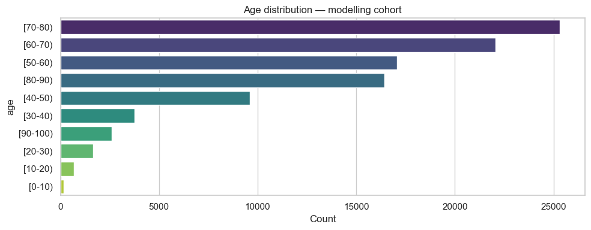

```
📊 Category Summary

column: age | total_n: 99,340 | n_unique: 10 | displayed: 10 | hidden: 0 | displayed_share_%: 100.00

category: [70-80) | count: 25329 | pct_of_total: 25.50 |

category: [60-70) | count: 22058 | pct_of_total: 22.20 |

category: [50-60) | count: 17060 | pct_of_total: 17.17 |

category: [80-90) | count: 16434 | pct_of_total: 16.54 |

category: [40-50) | count: 9607 | pct_of_total: 9.67 |

category: [30-40) | count: 3764 | pct_of_total: 3.79 |

category: [90-100) | count: 2589 | pct_of_total: 2.61 |

category: [20-30) | count: 1649 | pct_of_total: 1.66 |

category: [10-20) | count: 690 | pct_of_total: 0.69 |

category: [0-10) | count: 160 | pct_of_total: 0.16 |
```

Two analytical implications fall out. First, age is going to be a real predictor of readmission downstream — but the demographic centre of gravity is *already* in the at-risk geriatric range, so the differentiation will come from contrasts *within* the senior bands rather than between seniors and the under-40 tail. §5.2 will test that empirically. Second, my engineered `age_midpoint_squared` feature is justified by this distribution: a linear-only age term would force a model to fit a straight line through a distribution whose centre of mass sits in a narrow age band, and the quadratic gives the linear models the curvature they need. Tree models will use the linear term and ignore the quadratic; linear models will use both.

### 2.2 Gender distribution

The dataset records three gender categories: `Male`, `Female`, and `Unknown/Invalid`. The third category contains only three rows in the full admission table, and notebook `00`’s modelling-cohort builder dropped them as part of the cohort exclusions, so the version of the data I’m looking at here holds two values only.

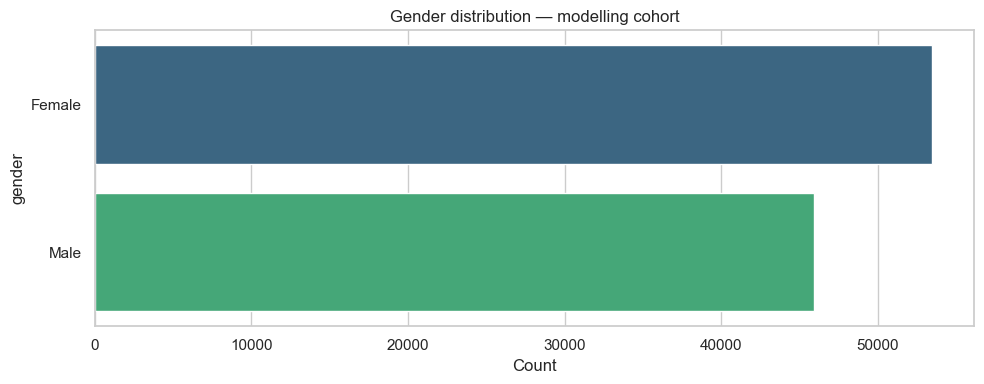

```
📊 Category Summary

column: gender | total_n: 99,340 | n_unique: 2 | displayed: 2 | hidden: 0 | displayed_share_%: 100.00

category: Female | count: 53454 | pct_of_total: 53.81 |

category: Male | count: 45886 | pct_of_total: 46.19 |
```

The split is **Female 53.81%** (53,454 admissions) and **Male 46.19%** (45,886) — slightly female-skewed but close enough to balanced that no analytical decision in this notebook depends on the imbalance. The skew is consistent with what one would expect from an older-skewed inpatient cohort in the United States: women live longer than men on average, and the [70-80), [80-90), and [90-100) age bands that dominate this dataset are exactly where the female-to-male ratio in the general population starts to widen. The gender skew here is a *demographic consequence* of the age distribution above, not an independent recruitment bias in the data.

Two implications. First, gender will enter the modelling notebook as a binary feature without any need for re-balancing. Second, when §5.6 looks at readmission rate by gender, any difference between the two arms will be measured against an honest denominator — each arm carries enough rows (~54k female, ~46k male) that confidence intervals on per-arm rates will be tight, and any meaningful difference will surface clearly rather than being lost in sampling noise.

Race in the source data is recorded as one of five categories — `Caucasian`, `AfricanAmerican`, `Hispanic`, `Asian`, `Other` — with a small share of admissions missing the field. Notebook `00`’s Silver layer left the categorical structure intact and the missing values as `pd.NA`; Gold’s `_sanitize_gold_strings` then converted them to the literal string `"Missing"` so downstream models can handle them without falling into NaN-comparison semantics.

A note on framing. Race in this dataset is a recorded *category* rather than a clinical mechanism. Any association between race and readmission that this notebook surfaces will be a *correlation* — most likely with confounding through socioeconomic factors, healthcare access, comorbidity profile, and admitting specialty patterns rather than through any direct biological pathway.

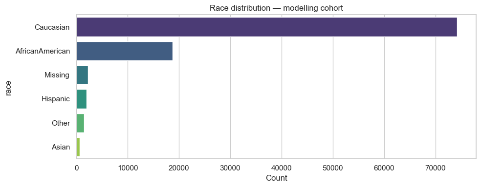

```
📊 Category Summary

column: race | total_n: 99,340 | n_unique: 6 | displayed: 6 | hidden: 0 | displayed_share_%: 100.00

category: Caucasian | count: 74220 | pct_of_total: 74.71 |

category: AfricanAmerican | count: 18772 | pct_of_total: 18.90 |

category: Missing | count: 2232 | pct_of_total: 2.25 |

category: Hispanic | count: 2017 | pct_of_total: 2.03 |

category: Other | count: 1471 | pct_of_total: 1.48 |

category: Asian | count: 628 | pct_of_total: 0.63 |
```

The distribution is heavily skewed toward two majority categories. **Caucasian** patients account for **74.71%** of admissions (74,220) and **AfricanAmerican** patients for **18.90%** (18,772) — together those two cover **93.61%** of the cohort. The remaining four categories sit in the long tail: **Missing** at **2.25%** (2,232), **Hispanic** at **2.03%** (2,017), **Other** at **1.48%** (1,471), and **Asian** at **0.63%** (628).

The skew has direct analytical consequences. Any per-race readmission rate the notebook reports later will carry tight confidence intervals for the two majority categories and meaningfully wider intervals for Hispanic, Other, Missing, and Asian — small differences in those four will not pass formal significance even when they look interesting on a bar chart. The chi-square test in the next cell takes this honestly: it tests whether the joint distribution of race and readmission departs from independence anywhere across all six categories.

The roughly 75-to-19 Caucasian-to-AfricanAmerican ratio is also relevant to the planned fairness audit in notebook `02`. The audit will measure how the predictive model performs across protected groups including race; the heavy concentration in two categories means the audit will have plenty of statistical power for the Caucasian-vs-AfricanAmerican comparison and progressively less for the smaller groups.

A first formal test: is race independent of 30-day readmission, or are the rates meaningfully different across groups?

```
Chi-square test of independence: race × readmitted_30d
============================================================
  H₀ : race and readmitted_30d are independent
  H₁ : race and readmitted_30d are associated
  α  : 0.05
------------------------------------------------------------
  Chi² statistic               =       26.884
  Degrees of freedom           = 5
  p-value                      = 0.0001
  Cramér's V (bias-corrected)  = 0.0148

  Effect size — Cohen's conventions for Cramér's V (dof = 1)
     negligible: V < 0.10  |  small: 0.10–0.20  |  moderate: 0.20–0.40  |  large: V ≥ 0.40
     → observed V = 0.0148 → negligible
------------------------------------------------------------
  Decision : REJECT H₀ at α = 0.05  (p = 0.0001 < 0.05)
  Reading  : The two variables are statistically associated, but the
             effect size is negligible — meaningful significance, not
             necessarily meaningful magnitude.

Readmission rate by race (%):
race
AfricanAmerican    11.45
Asian              10.35
Caucasian          11.53
Hispanic           10.51
Missing             8.42
Other               9.79
```

This is the classic **large-N paradox**: with **99,340 admissions**, the chi-square test has enormous statistical power, and even a vanishingly small departure from independence becomes statistically detectable. The p-value alone tells me nothing useful about whether the association matters; the effect size does.

The reading I take forward is: race and readmission are *not* independent, but the association is too weak to act as a primary driver of the modelling pipeline. Any predictive value race carries will most likely come through interactions and confounding rather than through a direct main effect, and the modelling notebook will encode race as one of several demographic features without any special treatment. The negligible effect size also informs how I’ll read the fairness audit in notebook `02`: a model that produces meaningfully different performance across racial groups would be doing so primarily because race correlates with other features (insurance, comorbidity profile, admitting specialty) rather than because the cohort base rates differ sharply by race.

This is also a useful illustration of the *p-value vs effect size* distinction that runs through the rest of this notebook: with ~99k rows, statistical significance is cheap, so I lean on effect-size measures (Cramér’s V, point-biserial r, rank-biserial r) to judge what is actually informative.

### 2.4 Payer mix

Payer code records the patient’s primary payer at admission — Medicare, Medicaid, private insurance carriers, self-pay, and so on. The full admission table holds **17 distinct payer codes** plus the engineered `Missing` category, with around **40%** of admissions missing the field. Missingness at this scale is itself meaningful: it almost certainly reflects hospitals where the payer code was not reliably captured at intake rather than admissions where no payer existed, and the modelling notebook will treat `Missing` as its own category rather than imputing.

The chart below is a Pareto plot — payer codes ranked left-to-right by admission count, with a cumulative-share curve overlaid. The Pareto framing is appropriate because payer mix tends to follow a power law, with a small number of dominant payers covering the bulk of admissions and a long tail of smaller payers contributing fractions of a percent each. The cumulative curve makes it easy to see how many payer codes are needed to cover, say, 80% of the active-payer mass, which informs the high-cardinality encoding strategy in notebook `02`.

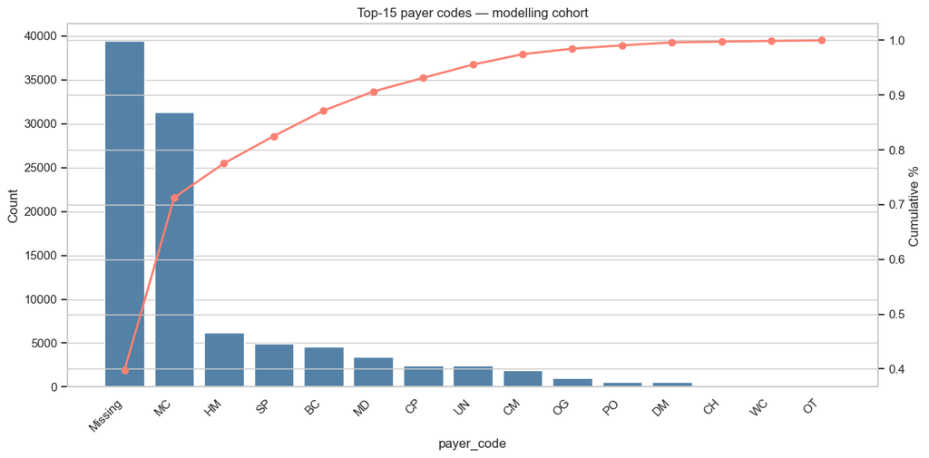

```
payer_code
Missing    39397
MC         31333
HM          6195
SP          4941
BC          4601
MD          3473
CP          2464
UN          2411
CM          1880
OG          1011
PO           585
DM           545
CH           142
WC           135
OT            92
Name: count, dtype: int64
Top-5 share of non-missing: 87.0%
```

Two analytical implications. First, the Medicare dominance is itself a demographic statement: Medicare is the primary US payer for patients aged 65 and over, and its dominance here echoes the heavy senior skew the age distribution showed in §2.1. The Cramér’s V matrix at the close of this section will quantify the strength of that age-payer association directly — and it does come back as the second-strongest demographic pair. Second, the heavy concentration in the top few payer codes tells the modelling notebook that target encoding is the right choice for this column: one-hot encoding 17 levels would explode the feature space unnecessarily, and target encoding will collapse the long tail into a single numeric value per code that captures the per-payer base rate without the dimensionality cost.

The high missingness rate (~40%) deserves one more comment. A model trained on a cohort where missing-payer is a category in its own right will learn whatever signal that category carries — and depending on which hospitals or admission types tend to leave the field blank, that signal may be substantial. §5 will check whether the Missing category has a different readmission rate from the recorded categories.

### 2.5 Top admitting specialties

Medical specialty records the specialty of the admitting physician — internal medicine, cardiology, family practice, and so on. This is the highest-cardinality categorical feature in the cohort: the column holds **73 distinct values** including the engineered `Missing` category, and around **49%** of admissions have it missing. The missingness rate roughly halves the effective coverage and will need a `Missing` category rather than imputation, exactly as in the payer-code case above.

The chart below shows the **top 15 admitting specialties** by admission count. I cap the display at 15 because the long tail extends well beyond that — the bottom ~58 specialties together account for under 5% of admissions and would crowd the chart without adding analytical signal. The printed Category Summary directly under the chart prints the exact counts plus the **displayed_share_%** field that quantifies how much of the cohort the top-15 actually covers.

The cardinality and the missingness rate together tell me everything I need to know about how this column will enter the modelling pipeline. **Target encoding** is the right move for notebook `02` — converting each specialty to its per-specialty readmission rate gives the model a single numeric value per category that compresses 73 levels into one feature, and the rare-category problem (specialties with fewer than ~30 admissions) gets handled smoothly because the encoder can fall back on a smoothed prior.

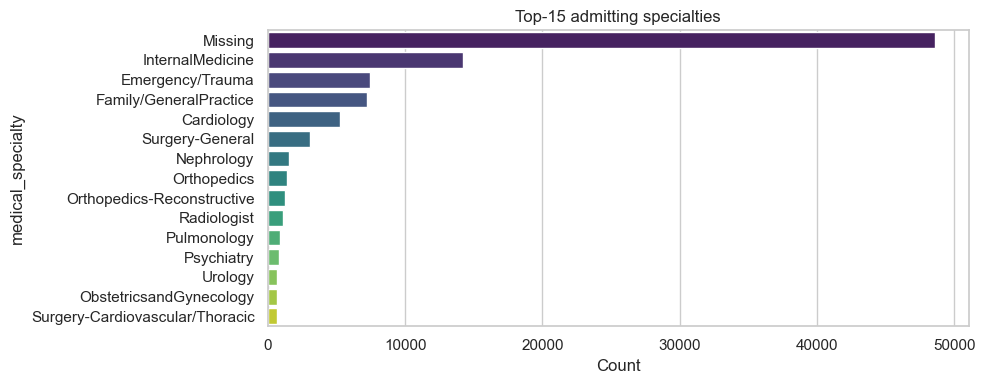

```
📊 Category Summary

column: medical_specialty | total_n: 99,340 | n_unique: 73 | displayed: 15 | hidden: 58 | displayed_share_%: 95.47

category: Missing | count: 48614 | pct_of_total: 48.94 |

category: InternalMedicine | count: 14237 | pct_of_total: 14.33 |

category: Emergency/Trauma | count: 7419 | pct_of_total: 7.47 |

category: Family/GeneralPractice | count: 7252 | pct_of_total: 7.30 |

category: Cardiology | count: 5278 | pct_of_total: 5.31 |

category: Surgery-General | count: 3059 | pct_of_total: 3.08 |

category: Nephrology | count: 1539 | pct_of_total: 1.55 |

category: Orthopedics | count: 1392 | pct_of_total: 1.40 |

category: Orthopedics-Reconstructive | count: 1230 | pct_of_total: 1.24 |

category: Radiologist | count: 1121 | pct_of_total: 1.13 |

category: Pulmonology | count: 854 | pct_of_total: 0.86 |

category: Psychiatry | count: 853 | pct_of_total: 0.86 |

category: Urology | count: 682 | pct_of_total: 0.69 |

category: ObstetricsandGynecology | count: 669 | pct_of_total: 0.67 |

category: Surgery-Cardiovascular/Thoracic | count: 642 | pct_of_total: 0.65 |
```

The top-15 displayed specialties cover **95.47%** of the cohort, leaving the bottom 58 specialties with under 5% of mass between them — clean Pareto behaviour. The largest single category is **Missing** at **48,614** admissions (**48.94%**) — the missingness rate dominates the column. Among the recorded specialties, **InternalMedicine** is the largest at **14,237** admissions (**14.33%**), unsurprising for a diabetic inpatient cohort where diabetic complications are most often handled on internal-medicine wards. **Emergency/Trauma** at **7,419** (**7.47%**), **Family/GeneralPractice** at **7,252** (**7.30%**), and **Cardiology** at **5,278** (**5.31%**) round out the top four.

Two analytical threads pick up later. First, the **48.94% missingness rate** in this column means that nearly half the cohort will land in the Missing specialty bucket, and the modelling notebook needs to test whether that bucket carries its own readmission-rate signal. Second, **Cardiology** appearing in the top four is consistent with the **Circulatory** primary-diagnosis dominance I’ll show in §3.1 — many of these admissions are diabetic patients admitted for cardiovascular events, with diabetes as a comorbidity rather than primary condition. That cross-feature association is exactly what the Cramér’s V matrix in the next subsection is designed to surface.

### 2.6 Demographic association matrix

To close the demographic profile, I check whether the five demographic features — age, gender, race, payer code, and admitting specialty — carry overlapping information. A high Cramér’s V between two of them would mean the second feature is largely redundant once the first is in the model, which has implications for the multicollinearity scan in §10 and the propensity-score covariate set in §8.

The chart below renders a Cramér’s V matrix as a heatmap, with the off-diagonal values printed inside each cell. Cramér’s V here is bias-corrected (Bergsma 2013) so that the values are comparable across pairs with different cardinalities — the unadjusted version is biased upward when one of the variables has many levels, which would distort the comparison between, say, gender × age (2 × 10 levels) and medical_specialty × payer_code (~73 × 18 levels). Below the heatmap, a ranked summary table prints the ten strongest pairs in descending order, with Cohen’s interpretation bands attached.

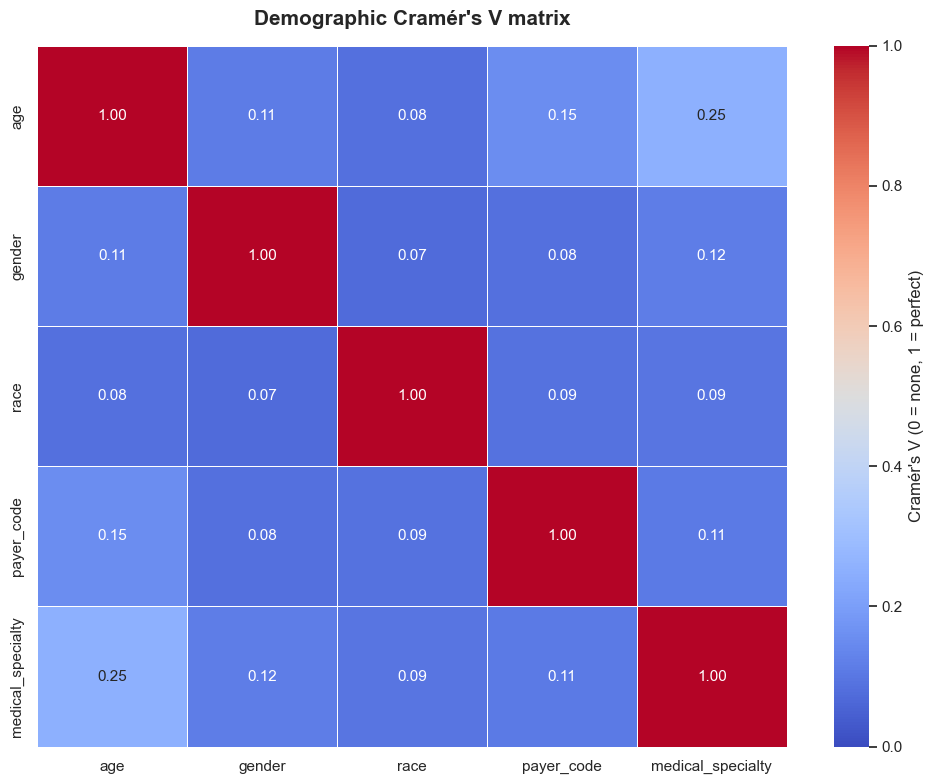

```
📊 Cramér's V — pairwise summary (bias-corrected, ranked)
======================================================================
  Cohen's conventions for Cramér's V (dof = 1):
     negligible: V < 0.10  |  small: 0.10–0.20
     moderate:   0.20–0.40 |  large: V ≥ 0.40
----------------------------------------------------------------------
     feature_a          feature_b  cramers_v
1          age  medical_specialty     0.2524
2          age         payer_code     0.1536
3       gender  medical_specialty     0.1151
4          age             gender     0.1117
5   payer_code  medical_specialty     0.1085
6         race  medical_specialty     0.0941
7         race         payer_code     0.0870
8          age               race     0.0847
9       gender         payer_code     0.0841
10      gender               race     0.0706
```

The matrix is mostly quiet. The strongest pair is **age × medical_specialty** at **V = 0.252**, which lands in the moderate band — older patients are systematically routed to different admitting specialties than younger ones (geriatrics, cardiology, internal medicine for the senior bands; paediatric subspecialties for the very young; obstetrics-related specialties for working-age women). This is mechanical rather than informational, but it is strong enough that the propensity model in §8 will need to handle the pair carefully — if both age and medical specialty enter the covariate set together, the coefficient on each will absorb part of what the other could explain.

The next-strongest pair is **age × payer_code** at **V = 0.154** (small) — Medicare eligibility kicks in at 65, so patients in the senior age bands are mechanically more likely to carry Medicare as their primary payer. This is again a structural rather than analytical association, and again worth flagging for the propensity model’s covariate handling.

Below those two, the rest of the matrix sits in the small-to-negligible range: **gender × medical_specialty** at **V = 0.115**, **age × gender** at **V = 0.112**, **payer_code × medical_specialty** at **V = 0.109**, **race × medical_specialty** at **V = 0.094**, **race × payer_code** at **V = 0.087**, **age × race** at **V = 0.085**, **gender × payer_code** at **V = 0.084**, and **gender × race** at **V = 0.071**. None of those pairs warrants special handling.

The two real findings — the moderate age-specialty association and the small age-payer association — are both expected given how US healthcare routes patients by age, and both will be visible in the multicollinearity scan in §10 when the engineered `prior_visits_x_age` interaction term shows up alongside the linear age term. With the demographic landscape mapped, I move to the clinical features.

## 3 · The Clinical Picture

This section profiles the clinical features of each admission: the primary diagnosis, the comorbidity load, the length of stay, the volume of in-hospital procedures, and the patient’s prior healthcare utilisation. These are the features I expect to drive readmission risk, and §5 will quantify exactly how strongly each one does. What I’m doing here is the structural step before the signal step: showing the *shape* of each feature, so that the per-feature readmission rates that appear later are read against the right population baseline.

The section closes with a Mann-Whitney U battery — a single statistical pass that compares the distribution of every continuous clinical feature between readmitted and not-readmitted patients, and ranks them by rank-biserial effect size. This is the first formal signal-ranking exercise in the notebook, and the ranking it produces sets up the rest of the analysis: the top-of-list features get full distributional overlays in §6.2, and the strongest predictors carry directly into the modelling decisions in §7’s univariate league table.

### 3.1 Primary diagnosis groups

The raw `diag_1` column holds the patient’s primary ICD-9 diagnosis code at admission, with **716 distinct values** in the modelling cohort. Working with that level of granularity is impractical: most codes appear in fewer than 50 admissions, the long tail dilutes any signal, and one-hot encoding would produce a dimensionality the model cannot use. The Silver layer’s `diag_1_group` collapses these 716 codes into **nine clinical groups** plus a residual “Other” bucket, using the standard ICD-9 grouping convention from Strack et al. (2014): Circulatory, Respiratory, Digestive, Diabetes, Injury, Musculoskeletal, Genitourinary, Neoplasms, Other. A tiny `Missing` category (20 admissions) catches rows where the underlying ICD-9 code didn’t map to any group.

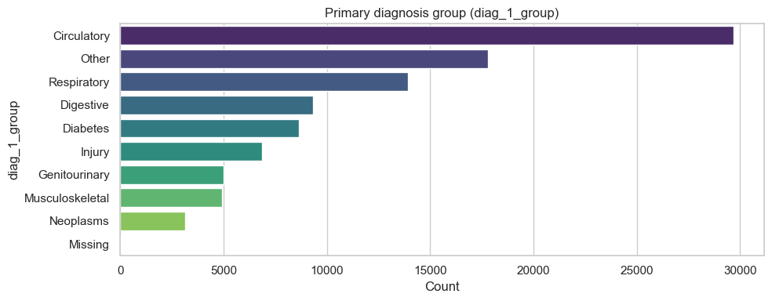

```
📊 Category Summary

column: diag_1_group | total_n: 99,340 | n_unique: 10 | displayed: 10 | hidden: 0 | displayed_share_%: 100.00

category: Circulatory | count: 29680 | pct_of_total: 29.88 |

category: Other | count: 17793 | pct_of_total: 17.91 |

category: Respiratory | count: 13934 | pct_of_total: 14.03 |

category: Digestive | count: 9333 | pct_of_total: 9.40 |

category: Diabetes | count: 8661 | pct_of_total: 8.72 |

category: Injury | count: 6851 | pct_of_total: 6.90 |

category: Genitourinary | count: 5002 | pct_of_total: 5.04 |

category: Musculoskeletal | count: 4935 | pct_of_total: 4.97 |

category: Neoplasms | count: 3131 | pct_of_total: 3.15 |

category: Missing | count: 20 | pct_of_total: 0.02 |
```

The distribution shows the expected dominance of cardiovascular admissions in a diabetic cohort. **Circulatory** diagnoses lead at **29.88%** of admissions (29,680), unsurprising given that cardiovascular comorbidity is the rule rather than the exception in diabetic inpatients. The “Other” bucket — the residual category for 716-code long tail entries that don’t map to one of the nine clinical groups — is the second-largest at **17.91%** (17,793). **Respiratory** sits at **14.03%** (13,934), **Digestive** at **9.40%** (9,333), and **Diabetes itself** as the primary diagnosis at **8.72%** (8,661) — meaning that in roughly nine out of ten admissions in this cohort, diabetes is comorbid rather than primary. **Injury** at **6.90%**, **Genitourinary** at **5.04%**, **Musculoskeletal** at **4.97%**, and **Neoplasms** at **3.15%** round out the distribution. The tiny `Missing` category holds just 20 admissions (0.02%).

Two analytical implications fall out. First, the diabetes-as-primary subgroup is small but interpretable: when a patient *is* admitted specifically for a diabetic event (DKA, hypoglycaemic crisis, severe hyperglycaemia), §5.3 will check whether they readmit at a different rate than patients admitted for cardiovascular or respiratory reasons with diabetes as a background condition. Second, the engineered `n_comorbidity_flags` feature in the next subsection will quantify *how many* of the three diagnosis positions carry a clinically grouped diagnosis — which is the difference between a single-system admission (one circulatory flag) and a multi-system one (circulatory + respiratory + diabetes simultaneously). The modelling notebook will lean heavily on the comorbidity flag count and on the per-group readmission rates that §5.3 produces.

### 3.2 Comorbidity load

The engineered `n_comorbidity_flags` feature counts how many of the three diagnosis positions on the admission record (`diag_1`, `diag_2`, `diag_3`) carry a code that maps to one of the three target clinical groups: circulatory, respiratory, or diabetes. The count ranges from **0** (none of the three positions carry one of those groups) to **3** (all three positions do). The intuition is that multi-system involvement is a stronger predictor of readmission than any single primary diagnosis — a patient simultaneously presenting cardiovascular, respiratory, and diabetic conditions is a fundamentally different risk profile from one with a single isolated condition.

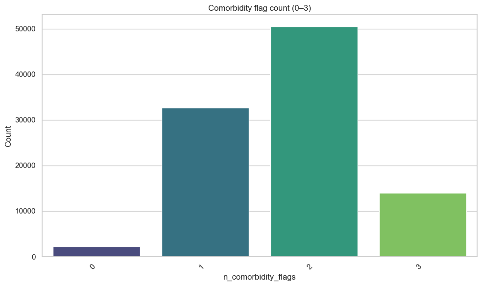

```
📊 Category Summary

column: n_comorbidity_flags | total_n: 99,340 | n_unique: 4 | displayed: 4 | hidden: 0 | displayed_share_%: 100.00

category: 2 | count: 50517 | pct_of_total: 50.85 |

category: 1 | count: 32662 | pct_of_total: 32.88 |

category: 3 | count: 13950 | pct_of_total: 14.04 |

category: 0 | count: 2211 | pct_of_total: 2.23 |
```

The modal value is **2** — most diabetic admissions present with two of the three target comorbidity classes coded across their diagnosis positions. The exact distribution: **flag count 2** dominates at **50.85%** of the cohort (50,517 admissions), **flag count 1** at **32.88%** (32,662), **flag count 3** at **14.04%** (13,950), and **flag count 0** at just **2.23%** (2,211). The mass is concentrated heavily in counts 1 and 2, which together hold **83.7%** of admissions.

Two analytical points follow. First, the modal-2 result confirms the engineered feature is well-calibrated for this cohort — the median admission carries two of the three target comorbidity flags, which is exactly the multi-system pattern the count was designed to capture. The Mann-Whitney U battery in §3.7 will tell me whether the difference between flag counts of 1, 2, and 3 actually translates to different readmission rates, and §6.1’s quantile-binned plot will visualise that relationship directly.

Second, the **flag count 0** subgroup is small but worth a thought. These admissions are diabetic — by construction; this is a diabetic-patient cohort — but their primary clinical issue at this admission was something other than circulatory, respiratory, or diabetic. They might be readmitted at a different rate than the multi-system admissions, and if they are, the modelling notebook needs to make sure the `n_comorbidity_flags = 0` category is not lost in encoding. §7’s univariate league table will surface that question implicitly through the `diag_1_is_*` dummy rankings.

### 3.3 Length of stay distribution

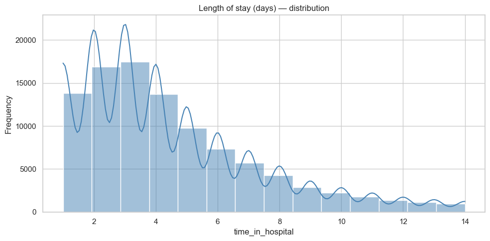

```
📊 Distribution Summary
column: time_in_hospital | count: 99340 | mean: 4.38 | median: 4.00 | std: 2.97 | min: 1.00 | p5: 1.00 | p95: 11.00 | p99: 14.00 | max: 14.00 | skew: 1.14 | kurtosis: 0.89 |
```

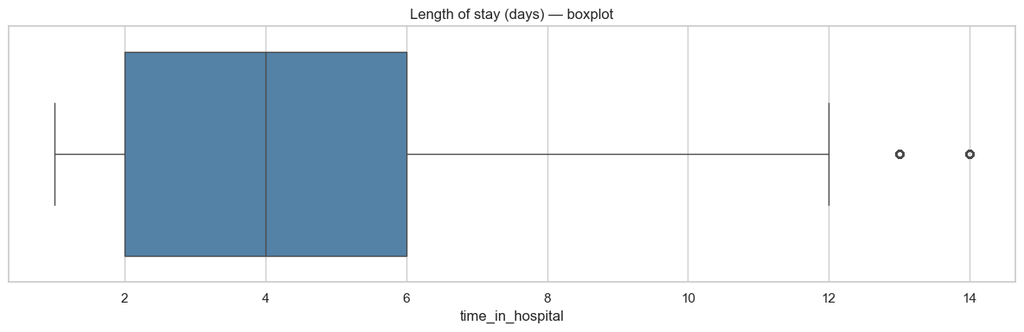

```
📊 Boxplot Summary Statistics
column: time_in_hospital | count: 99340 | min: 1.00 | q1: 2.00 | median: 4.00 | q3: 6.00 | max: 14.00 | range: 13.00 | iqr: 4.00 | skew: 1.14 | kurtosis: 0.89 | number_of_outliers: 2147 | outliers_zscore: 995 |
```

The two plots together give the full picture: a histogram with the printed Distribution Summary, and a boxplot with the printed Boxplot Summary Statistics. Length of stay is right-skewed with a **mean of 4.38 days**, a **median of 4 days**, and a **standard deviation of 2.97 days**. The Q1–Q3 range is **2 to 6 days**, and the maximum is censored at **14 days**. The 95th percentile is **11 days** and the 99th percentile **14 days** — the right tail compresses against the censoring cap. The skew is **1.14** with a kurtosis of **0.89** — heavier in the right tail than a normal distribution but not dramatically so.

The IQR-based outlier count is **2,147** admissions, with **995** of them flagged as 3-sigma outliers on the z-score test. In a clinical context these are not data-quality outliers — they are clinically meaningful long stays, with the modal long-stay admission sitting at the 14-day censoring cap. The right tail represents patients with severe complications, multiple procedures, or post-acute recovery needs that prevented earlier discharge; their readmission risk is substantively higher than the median patient’s, and §5.5 will quantify that directly.

Two analytical threads pick up later. First, length of stay enters the modelling notebook as a continuous feature, and the right-skew is mild enough that no log transform is necessary — the modelling pipeline will use the raw integer values. Second, length of stay shows up in §9 as a confounder for the HbA1c testing question: longer-stay patients have more time and opportunity for the lab order, and the propensity-score model in §8.4 will need to control for it.

### 3.4 Lab procedure volume

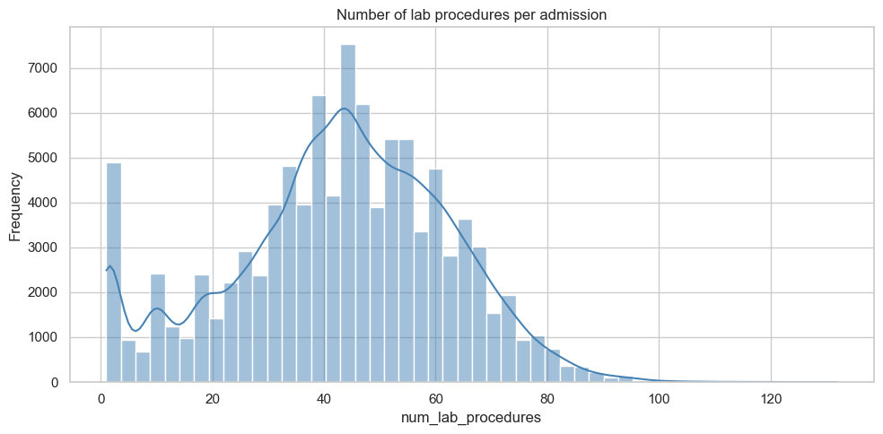

```
📊 Distribution Summary
column: num_lab_procedures | count: 99340 | mean: 42.91 | median: 44.00 | std: 19.61 | min: 1.00 | p5: 4.00 | p95: 73.00 | p99: 84.00 | max: 132.00 | skew: -0.24 | kurtosis: -0.25 |
```

The Distribution Summary anchors the shape: **mean 42.91**, **median 44.00**, **std 19.61**, **min 1.00**, **p5 4.00**, **p95 73.00**, **p99 84.00**, **max 132.00**, with **skew −0.24** and **kurtosis −0.25**. The negative skew is small but real. Visually, while the absolute maximum (132) stretches out a long right tail, the skewness is driven negative because the median sits above the mean, heavily weighted by a dense concentration of admissions between 40 and 60 procedures alongside a sharp, distinct spike of low-intensity admissions right at the left boundary. The kurtosis just below 0 means it has slightly thinner tails than a normal distribution, tapering off predictably past the 95th percentile.

Mechanically, this feature counts the total number of laboratory procedures ordered during the admission. It is essentially a proxy for clinical attention intensity: a sicker or more diagnostically uncertain patient generates more lab orders, and a routine admission generates fewer. Reading the feature this way matters when interpreting any predictive signal it carries — `num_lab_procedures` is unlikely to be a *cause* of readmission risk, but it is likely to be a *correlate* of underlying clinical complexity, which is itself the cause. The modelling notebook will use the raw count as a continuous feature; the SHAP analysis in notebook `02` will show whether the feature contributes meaningfully and whether it does so in the direction the proxy interpretation predicts.

### 3.5 Prior utilisation

The engineered `n_prior_visits_total` feature aggregates the patient’s outpatient, emergency, and inpatient visit counts in the year preceding the index admission. It is one of the strongest candidate predictors I expect to find: high prior utilisation indicates a patient who is already in active contact with the healthcare system, with chronic conditions or unstable management driving repeated visits, and that pattern almost mechanically extends into post-discharge readmission risk.

The chart below uses a log-scaled x-axis. The log scale is essential here — the raw distribution is dominated by patients with zero prior visits, and a linear-scale histogram would compress the tail into invisibility.

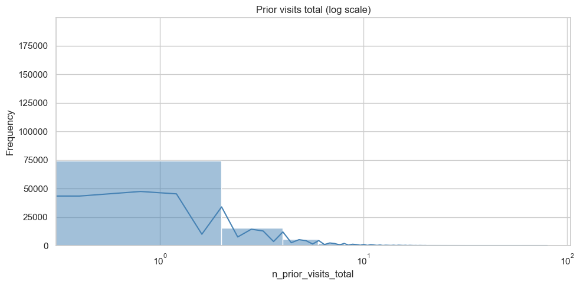

```
📊 Distribution Summary
column: n_prior_visits_total | count: 99340 | mean: 1.20 | median: 0.00 | std: 2.29 | min: 0.00 | p5: 0.00 | p95: 5.00 | p99: 10.00 | max: 80.00 | skew: 5.35 | kurtosis: 68.06 |
```

The Distribution Summary anchors the shape: **mean 1.20**, **median 0**, **std 2.29**, with a **maximum of 80** prior visits, **skew 5.35** and **kurtosis 68.06** — the distribution is dramatically heavy-tailed. Most admissions come from patients with zero or low prior visits: the **5th and 50th percentiles are both 0**, the **95th percentile is 5**, and the **99th percentile is 10**. The very long tail past 10 visits represents a small group of very high-utilisation patients, and the maximum value of 80 is the single most extreme admission in the cohort.

The bimodal-by-construction shape — a large mass at zero plus a long thin tail — has direct modelling implications. Linear models will struggle with this distribution unless it is transformed, because the zero-mass dominates any linear coefficient and pulls the fitted relationship toward zero. Tree models handle it natively because they split on raw thresholds. §6.2 below shows the distribution overlaid by readmission status, which is where this feature really earns its place: the readmitted patients are visibly shifted into the long tail relative to the not-readmitted patients, and the rank-biserial correlation in §3.7 will quantify that shift formally.

The high-utilisation tail is also the subgroup most likely to drive any aggregate effect. A small fraction of patients with disproportionately high prior visit counts can dominate group-level statistics, and §6.1’s quantile-binned readmission rate will show whether the readmission rate climbs monotonically with prior visits or whether it plateaus at the very top.

### 3.6 Length of stay by primary diagnosis

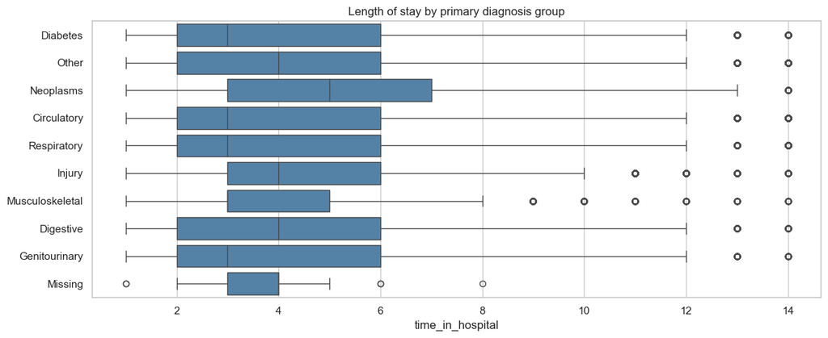

```
📊 Boxplot Summary Statistics (per category)

category: Circulatory | count: 29680 | min: 1.00 | q1: 2.00 | median: 3.00 | q3: 6.00 | max: 14.00 | range: 13.00 | iqr: 4.00 | skew: 1.14 | kurtosis: 0.92 | number_of_outliers: 537 | outliers_zscore: 537 |

category: Diabetes | count: 8661 | min: 1.00 | q1: 2.00 | median: 3.00 | q3: 6.00 | max: 14.00 | range: 13.00 | iqr: 4.00 | skew: 1.20 | kurtosis: 0.93 | number_of_outliers: 198 | outliers_zscore: 87 |

category: Digestive | count: 9333 | min: 1.00 | q1: 2.00 | median: 4.00 | q3: 6.00 | max: 14.00 | range: 13.00 | iqr: 4.00 | skew: 1.16 | kurtosis: 1.05 | number_of_outliers: 152 | outliers_zscore: 152 |

category: Genitourinary | count: 5002 | min: 1.00 | q1: 2.00 | median: 3.00 | q3: 6.00 | max: 14.00 | range: 13.00 | iqr: 4.00 | skew: 1.19 | kurtosis: 1.10 | number_of_outliers: 72 | outliers_zscore: 72 |

category: Injury | count: 6851 | min: 1.00 | q1: 3.00 | median: 4.00 | q3: 6.00 | max: 14.00 | range: 13.00 | iqr: 3.00 | skew: 1.06 | kurtosis: 0.81 | number_of_outliers: 387 | outliers_zscore: 71 |

category: Missing | count: 20 | min: 1.00 | q1: 3.00 | median: 4.00 | q3: 4.00 | max: 8.00 | range: 7.00 | iqr: 1.00 | skew: 0.68 | kurtosis: 1.38 | number_of_outliers: 5 | outliers_zscore: 0 |

category: Musculoskeletal | count: 4935 | min: 1.00 | q1: 3.00 | median: 3.00 | q3: 5.00 | max: 14.00 | range: 13.00 | iqr: 2.00 | skew: 1.48 | kurtosis: 2.76 | number_of_outliers: 271 | outliers_zscore: 74 |

category: Neoplasms | count: 3131 | min: 1.00 | q1: 3.00 | median: 5.00 | q3: 7.00 | max: 14.00 | range: 13.00 | iqr: 4.00 | skew: 0.74 | kurtosis: -0.24 | number_of_outliers: 52 | outliers_zscore: 0 |

category: Other | count: 17793 | min: 1.00 | q1: 2.00 | median: 4.00 | q3: 6.00 | max: 14.00 | range: 13.00 | iqr: 4.00 | skew: 1.07 | kurtosis: 0.49 | number_of_outliers: 640 | outliers_zscore: 0 |

category: Respiratory | count: 13934 | min: 1.00 | q1: 2.00 | median: 3.00 | q3: 6.00 | max: 14.00 | range: 13.00 | iqr: 4.00 | skew: 1.16 | kurtosis: 0.94 | number_of_outliers: 231 | outliers_zscore: 231 |
```

The boxplot stratifies length of stay across the nine diagnosis groups, with summary statistics printed for each. The medians and IQRs are surprisingly similar: most diagnosis groups have a **median LOS of 3–4 days** and a **Q3 of 5–7 days**. The boxes overlap heavily — most diabetic admissions take roughly the same time to clear regardless of the triggering diagnosis.

A few groups stand out modestly. **Neoplasms** has the highest median at **5 days** and the widest Q3 at **7 days** — cancer-related admissions tend to be more complex and take longer to discharge (n=3,131; skew 0.74, the most symmetric of any group). **Circulatory**, the largest group by far (n=29,680), sits at a **median of 3 days** and dominates the cohort’s overall LOS distribution. **Injury** has a higher Q1 at **3 days** than most groups, suggesting that even the shortest injury admissions take longer to clear than the shortest admissions of other types — likely reflecting required observation periods after trauma. **Musculoskeletal** is unusually compact (IQR = 2 days, kurtosis 2.76) — the tightest stay-length distribution in the cohort.

The “Missing” category is a tiny stratum (20 admissions) and its boxplot is not informative — the small sample is noted for transparency but does not enter any analytical claim.

The modest variation across diagnosis groups is itself useful information for the modelling notebook. It tells me that length of stay is not heavily confounded with primary diagnosis — the two features carry largely independent information, which means notebook `02` can use them both as covariates without worrying that one is a noisy proxy for the other.

### 3.7 Mann-Whitney U battery — continuous clinical features vs readmission

This is the first formal statistical battery in the notebook. For each continuous clinical feature, I run a Mann-Whitney U test comparing the feature’s distribution between readmitted (`readmitted_30d == 1`) and not-readmitted (`readmitted_30d == 0`) patients, then report the rank-biserial correlation — a unit-free effect size between -1 and +1 that quantifies the magnitude of the distributional shift.

I use Mann-Whitney rather than a t-test for two reasons. First, several of the continuous features (prior visits, number of inpatient visits, number of emergency visits) are heavily right-skewed with mass concentrated at zero — exactly the conditions under which the t-test’s normality assumption breaks. Second, the rank-biserial r is more robust to outliers than Pearson’s r, and the cohort has plenty of clinically-meaningful long-tail outliers in features like `n_prior_visits_total` that would distort a parametric comparison.

The output below ranks every continuous clinical feature by absolute rank-biserial r, descending. This ranking sets up the rest of the notebook: the top features get full distributional overlays in §6.2, the strongest predictors carry into §7’s univariate league table, and the modelling notebook in `02` will spend most of its feature-importance attention on the top of this list.

```
Mann-Whitney U battery — continuous clinical features vs readmitted_30d
===============================================================================================
                 feature  median_readmit  median_no_readmit           U_stat  p_value  rank_biserial_r  abs_r
1       number_inpatient          0.0000             0.0000 604,789,932.5000   0.0000          -0.2145 0.2145
2   n_prior_visits_total          1.0000             0.0000 601,737,209.5000   0.0000          -0.2084 0.2084
3       time_in_hospital          4.0000             4.0000 545,465,728.0000   0.0000          -0.0954 0.0954
4       number_diagnoses          9.0000             8.0000 541,796,552.5000   0.0000          -0.0880 0.0880
5        num_medications         16.0000            15.0000 541,381,148.0000   0.0000          -0.0872 0.0872
6       number_emergency          0.0000             0.0000 529,815,600.5000   0.0000          -0.0640 0.0640
7       med_change_ratio          0.0000             0.0000 527,164,784.0000   0.0000          -0.0586 0.0586
8         n_meds_changed          0.0000             0.0000 524,189,520.5000   0.0000          -0.0527 0.0527
9     num_lab_procedures         45.0000            44.0000 519,788,577.0000   0.0000          -0.0438 0.0438
10          age_midpoint         65.0000            65.0000 519,498,010.0000   0.0000          -0.0432 0.0432
11     number_outpatient          0.0000             0.0000 518,223,877.0000   0.0000          -0.0407 0.0407
12        num_procedures          1.0000             1.0000 494,087,647.5000   0.1528           0.0078 0.0078
13   n_comorbidity_flags          2.0000             2.0000 501,485,752.0000   0.1781          -0.0071 0.0071
14     n_meds_prescribed          1.0000             1.0000 501,446,578.5000   0.1954          -0.0070 0.0070
```

Below the top five, the effect sizes drop further. number_emergency at r = −0.064, med_change_ratio at r = −0.059, n_meds_changed at **r = −0.053, num_lab_procedures at** r = −0.044, age_midpoint at *r = −0.043, number_outpatient at **r = −0.041 — all in the negligible band by Cohen’s bands. The bottom of the table holds features with rank-biserial r values close to zero: num_procedures (r = +0.008, p = 0.15, not significant), n_comorbidity_flags (r = −0.007, p = 0.18, not significant), n_meds_prescribed (r = −0.007, p = 0.20, not significant).. The non-significance of these three is noteworthy — they are the only continuous features in the battery whose Mann-Whitney p-values do not reject independence with the target.

A note on Cohen’s interpretation bands for rank-biserial r. Conventionally, **|r| < 0.10** is negligible, **0.10 ≤ |r| < 0.30** is small, **0.30 ≤ |r| < 0.50** is moderate, and **|r| ≥ 0.50** is large. By that standard, only `number_inpatient` and `n_prior_visits_total` cross from negligible into small territory — *no single continuous feature in this cohort reaches a moderate effect size on the readmission target on its own*. This is consistent with the published literature on this dataset, which reports AUC ceilings in the **0.65–0.70** band for readmission prediction; the signal is genuinely diffuse, and the modelling notebook’s job will be to combine many small effects into a useful aggregate score rather than to ride a single dominant predictor.

The full ranking points forward to two specific sections. §6.1 takes the top-six features by effect size and renders the rate-by-quantile plot for each, which surfaces the *shape* of the relationship. §7’s univariate league table extends the same exercise to categorical features.

## 4 · The Medication Picture

This dataset has 23 medication columns covering individual diabetic agents and combination therapies — metformin, glipizide, glyburide, insulin, and 19 others, each recorded as one of `{No, Steady, Up, Down}` indicating whether the medication was prescribed and how its dose changed during the admission. Most of these columns are sparse: the diagnostic in §1 already flagged **13 medication columns as near-zero-variance** and **2 columns** (`examide`, `citoglipton`) as fully constant.

This section profiles the medication landscape in three steps. First, the high-level binary `diabetes_med` flag and the dominant `insulin` regimen breakdown — the two columns that carry meaningful variance. Second, a panel grid showing the near-zero-variance landscape so the reader can see exactly how thin the long tail is. Third, the `change` flag and its association with the readmission target. The point is to motivate the drop-list decisions the modelling notebook will make: which medications stay as features, which get aggregated into engineered counts, which are dropped entirely.

### 4.1 Diabetes medication prescribed

The `diabetes_med` column is a high-level binary flag indicating whether *any* diabetic medication was prescribed during the admission. It collapses the 23 individual medication columns into a single yes/no indicator that the modelling notebook can use without engaging the full sparse medication landscape.

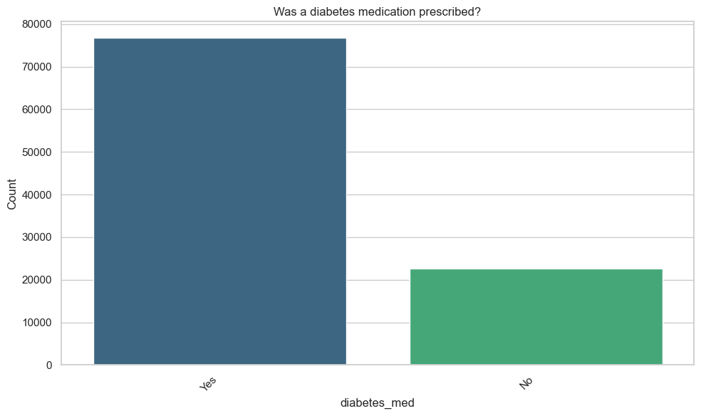

```
📊 Category Summary

column: diabetes_med | total_n: 99,340 | n_unique: 2 | displayed: 2 | hidden: 0 | displayed_share_%: 100.00

category: Yes | count: 76717 | pct_of_total: 77.23 |

category: No | count: 22623 | pct_of_total: 22.77 |
```

**Yes 77.23%** (76,717 admissions), **No 22.77%** (22,623). Roughly three-quarters of admissions have at least one diabetic medication on the chart, leaving a substantial **22.77%** without. In a diabetic-patient cohort that is itself an interesting subgroup. The 22.77% no-medication admissions are most likely either patients managed by lifestyle intervention alone (Type 2 diabetes in early stages or well-controlled), patients admitted for non-diabetic reasons where the home medication regimen was held during the admission, or patients whose diabetes is documented in the diagnosis codes but whose inpatient medication chart simply does not record diabetic agents.

The split is meaningful for the modelling notebook in two ways. First, the binary flag is itself a usable feature — §7’s univariate league table will quantify how strongly it associates with the readmission target. Second, the 22.77% no-medication subgroup will need to be cleanly distinguishable from the 77.23% medicated subgroup in any feature engineering that involves the medication columns; the engineered `n_meds_prescribed` count handles this by summing across the 23 columns, with the no-medication subgroup landing at zero.

### 4.2 Insulin regimen breakdown

Insulin is the most frequently used medication in this cohort and is the single drug column with enough variance to carry useful signal on its own. Unlike the other 22 medication columns, insulin has all four status levels populated meaningfully: `No` (no insulin during admission), `Steady` (continued at home dose), `Up` (dose increased), `Down` (dose decreased).

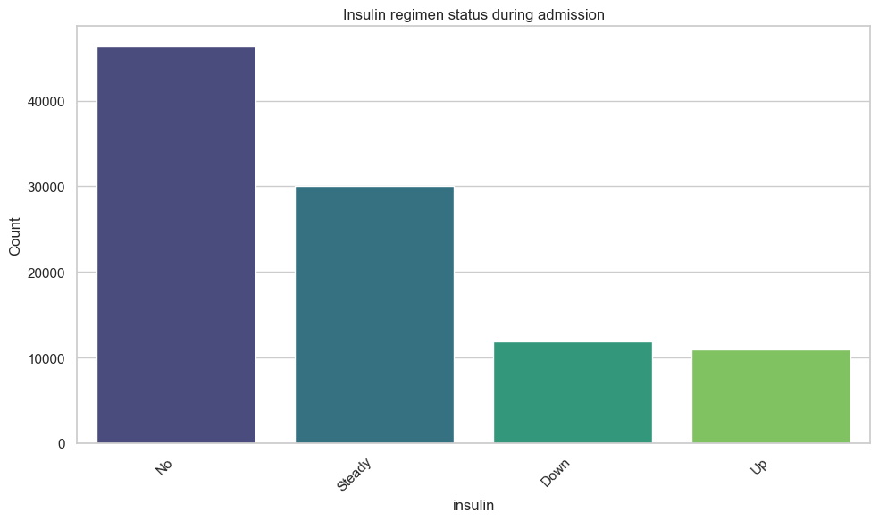

```
📊 Category Summary

column: insulin | total_n: 99,340 | n_unique: 4 | displayed: 4 | hidden: 0 | displayed_share_%: 100.00

category: No | count: 46376 | pct_of_total: 46.68 |

category: Steady | count: 30069 | pct_of_total: 30.27 |

category: Down | count: 11908 | pct_of_total: 11.99 |

category: Up | count: 10987 | pct_of_total: 11.06 |
```

The breakdown: **No 46.68%** (46,376), **Steady 30.27%** (30,069), **Down 11.99%** (11,908), **Up 11.06%** (10,987). About **53%** of admissions have insulin on the regimen, with `Steady` being the dominant active status — the patient continued whatever home regimen they were on. The `Up` and `Down` categories together account for **23.05%** of admissions, meaning a non-trivial fraction of patients had their insulin dose actively adjusted during the stay (slightly more Down-titrations than Up-titrations).

The dose-adjustment categories are clinically informative. An `Up` titration during admission signals that the inpatient team identified inadequate glycaemic control on the home regimen and intensified treatment; a `Down` titration signals the opposite. Both are clinical decisions that reflect the team’s read of the patient’s diabetic status, and both could plausibly correlate with readmission risk in opposite directions — §7’s league table will surface whether they do.

The four-level structure makes insulin one of the few medication columns that survives notebook `02`’s drop list intact. Most of the other 22 medication columns will be either dropped (the two fully constant ones) or aggregated into engineered counts (the 13 near-zero-variance ones). Insulin enters the model as its own categorical feature, and §7’s league table will rank it alongside the engineered features to confirm the decision was right.

### 4.3 Near-zero-variance medication landscape

The diagnostic in §1 flagged **13 medication columns as near-zero-variance** and **2 columns** (`examide`, `citoglipton`) as fully constant — every row in the cohort has the same value. The flag is a warning that the column carries essentially no usable variance for the modelling notebook: a feature where 99%+ of rows share a single value cannot reliably distinguish between readmitted and not-readmitted patients on its own.

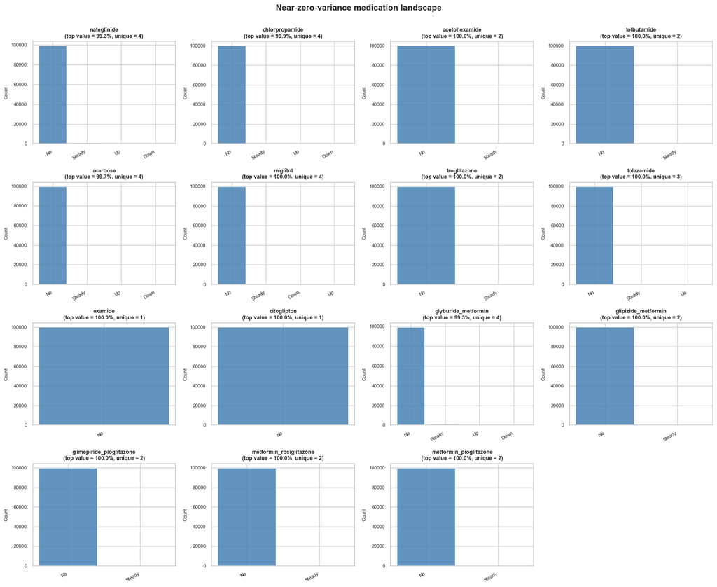

For the modelling notebook this confirms my plan. The two fully constant columns (`examide`, `citoglipton`) get **dropped** unconditionally — they cannot improve any model under any encoding. The 13 near-zero-variance columns get either dropped or aggregated into the engineered `n_meds_prescribed` and `n_meds_changed` counts that already capture whatever residual information they hold. Including them as standalone features would inflate the model’s dimensionality without adding signal, and a regularised linear model would zero them out anyway.

The next subsection prints the inventory in tabular form for narrative reference, with the dominant-value share and the count of non-dominant rows per column.

### 4.4 NZV companion summary table

```
NZV medication summary — sorted by dominant-value share
================================================================================
                      column dominant_value  dominant_share_%  n_unique  n_minority_rows
1                    examide             No           100.000         1                0
2                citoglipton             No           100.000         1                0
3              acetohexamide             No            99.999         2                1
4   glimepiride_pioglitazone             No            99.999         2                1
5     metformin_pioglitazone             No            99.999         2                1
6    metformin_rosiglitazone             No            99.998         2                2
7               troglitazone             No            99.997         2                3
8        glipizide_metformin             No            99.987         2               13
9                tolbutamide             No            99.979         2               21
10                  miglitol             No            99.962         4               38
11                tolazamide             No            99.961         3               39
12            chlorpropamide             No            99.914         4               85
13                  acarbose             No            99.693         4              305
14               nateglinide             No            99.306         4              689
15       glyburide_metformin             No            99.297         4              698
```

The table makes the asymmetry explicit. The two fully constant columns — `examide` and `citoglipton` — sit at **100% dominance** with **0 minority rows** and a single unique value each; they will be dropped unconditionally. Below them, several columns have fewer than **100 minority rows** out of 99,340 admissions: `acetohexamide` (1), `glimepiride_pioglitazone` (1), `metformin_pioglitazone` (1), `metformin_rosiglitazone` (2), `troglitazone` (3), `glipizide_metformin` (13), `tolbutamide` (21), `miglitol` (38), `tolazamide` (39), `chlorpropamide` (85) — far too sparse to support stable coefficient estimates in any linear model and providing essentially no split power for tree models either.

The bottom of the table holds the columns with marginally more variance: **`acarbose`** at **305** minority rows, **`nateglinide`** at **689**, and **`glyburide_metformin`** at **698** non-dominant rows. These three are still near-zero-variance by the conventional **>99% dominance** threshold, but they carry enough non-dominant rows that an aggressive modelling experiment might keep them as engineered indicator flags. The pragmatic choice for notebook `02` is to drop all 13 near-zero-variance columns and let the engineered medication aggregates (`n_meds_prescribed`, `n_meds_changed`, `med_change_ratio`) carry whatever signal they collectively hold.

### 4.5 Medication regimen change

The `change` column flags whether *any* diabetic medication was added, removed, or had its dose changed during the admission, taking values `Ch` (changed) or `No` (no change). This is potentially informative — clinical decisions to adjust a regimen mid-admission reflect the inpatient team’s judgement about how well the patient was being managed before, and that judgement may correlate with the readmission risk going forward.

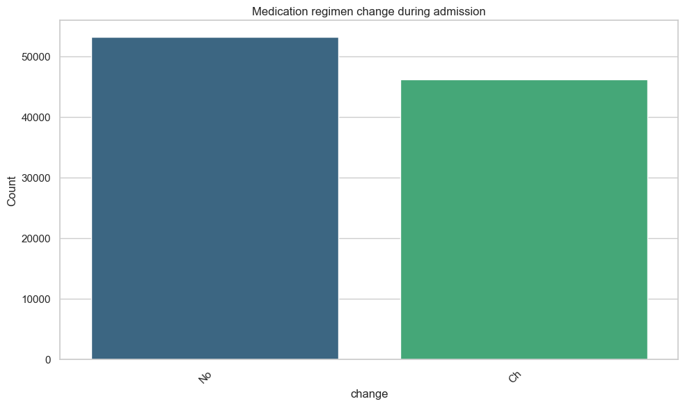

```
📊 Category Summary

column: change | total_n: 99,340 | n_unique: 2 | displayed: 2 | hidden: 0 | displayed_share_%: 100.00

category: No | count: 53220 | pct_of_total: 53.57 |

category: Ch | count: 46120 | pct_of_total: 46.43 |
```

```
Chi-square test of independence: change × readmitted_30d
============================================================
  H₀ : medication regimen change and readmitted_30d are independent
  H₁ : medication regimen change and readmitted_30d are associated
  α  : 0.05
------------------------------------------------------------
  Chi² statistic               =       34.151
  Degrees of freedom           = 1
  p-value                      = 0.0000
  Cramér's V (bias-corrected)  = 0.0183

  Effect size — Cohen's conventions for Cramér's V (dof = 1)
     negligible: V < 0.10  |  small: 0.10–0.20  |  moderate: 0.20–0.40  |  large: V ≥ 0.40
     → observed V = 0.0183 → negligible
------------------------------------------------------------
  Decision : REJECT H₀ at α = 0.05  (p = 0.0000 < 0.05)
  Reading  : Regimen change and 30-day readmission are statistically
             associated, with a negligible effect size.

Readmission rate by regimen change status (%):
change
Ch    12.02
No    10.84
```

The split is **No 53.57%** (53,220) / **Ch 46.43%** (46,120) — close to balanced. The chi-square test is statistically significant (**χ² = 34.15** on **1** degree of freedom, **p ≈ 0**), but the effect size is **Cramér’s V = 0.0183** — *negligible* by Cohen’s conventions. This is, again, the large-N paradox: with **99,340 admissions**, a tiny departure from independence becomes statistically detectable, and the p-value alone is uninformative about whether the association matters analytically.

The per-status readmission rates make the size of the effect concrete: the **`Ch` (changed) arm** readmits at **12.02%**, and the **`No` (unchanged) arm** readmits at **10.84%** — a **1.18 percentage point** absolute difference. The direction is the one I would expect: patients whose regimen was actively adjusted during the stay readmit at a slightly higher rate, consistent with the interpretation that a regimen change is a marker of an underlying clinical instability rather than a prophylactic adjustment. But the magnitude is too small to drive predictive modelling on its own, and the modelling notebook will use the `change_flag` column primarily as a small-effect input that the gradient-boosting models can combine with stronger features.

A note for the modelling pipeline. The `change` column is a string-form duplicate of the engineered `change_flag` integer column the Silver layer produces; both encode the same underlying signal. Notebook `02`’s preprocessing will drop `change` and keep `change_flag` to avoid feeding the same information twice into the model. §7’s univariate league table makes that redundancy visible (both appear at the same Cramér’s V).

## 5 · The Target — 30-Day Readmission

This section profiles the target variable in isolation, then stratifies it across age bands, primary diagnosis, discharge disposition, and length-of-stay quantiles. The point of the section is to give a clear baseline rate for the cohort, then to show which features carry the most signal *visually and statistically* before the formal bivariate scan in §6 and §7 produces the consolidated ranking.

A note on the test choice. For each stratifying variable I pair the readmission-rate visualisation with an appropriate hypothesis test: chi-square for categorical strata, Kruskal-Wallis for ordered categorical strata where the rank-based test is more appropriate than the nominal one. Each test reports both a p-value and an effect size (Cramér’s V or epsilon-squared), and I read both together — the p-value tells me whether the effect is detectable, the effect size tells me whether it matters.

### 5.1 Class balance

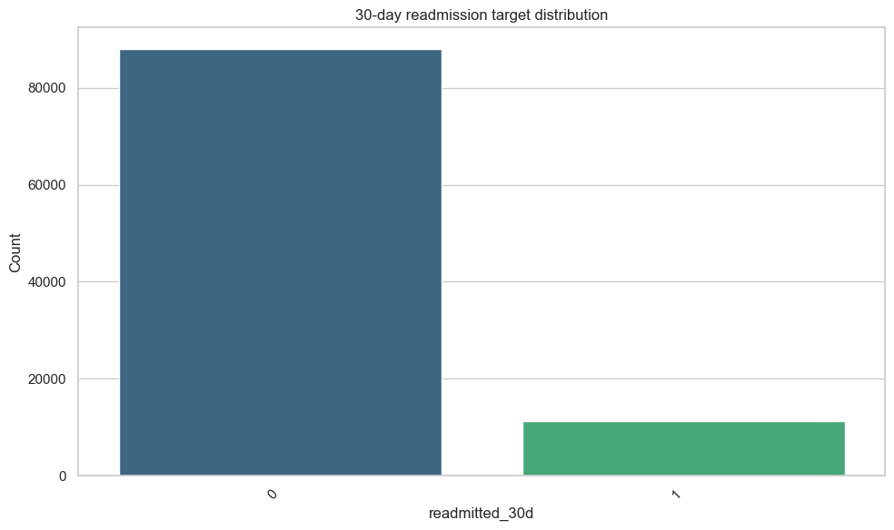

```
📊 Category Summary

column: readmitted_30d | total_n: 99,340 | n_unique: 2 | displayed: 2 | hidden: 0 | displayed_share_%: 100.00

category: 0 | count: 88026 | pct_of_total: 88.61 |

category: 1 | count: 11314 | pct_of_total: 11.39 |

Positive class rate: 11.39%
Imbalance ratio (negative:positive): 7.8 : 1
```

The positive class rate is **11.39%** (11,314 admissions readmitted within 30 days, 88,026 not) — moderately imbalanced but not extreme. The imbalance ratio is **7.8 to 1** (negative to positive), meaning a baseline classifier predicting “no readmission” for everyone would achieve **88.61% accuracy** while having zero clinical utility. This is the canonical class-imbalance situation, and accuracy is the wrong evaluation metric for it; notebook `02` will lean on **ROC-AUC** and **PR-AUC** as the primary ranking metrics and on **Youden’s J** for threshold optimisation.

The 11.39% rate also calibrates expectations for the modelling chapter. The published literature on this dataset reports **AUC ceilings in the 0.65–0.70 band** — meaning even strong models on this cohort produce only modest discriminative power, and the goal is a defensible, well-diagnosed model rather than a Kaggle-style chase of the last decimal point. Class-weighted training and SMOTE oversampling are both planned as part of the imbalance ladder in notebook `02`, and the threshold-optimisation step will surface the recall/precision trade-off explicitly so the operating point can be chosen by the clinical team rather than baked in by default.

A second implication: the imbalance is mild enough that the 11.39% positive class will appear in every cross-validation fold with reasonable density. §11 confirms that the patient-level GroupKFold split produces five folds with nearly identical positive rates, which means any cross-fold variance in modelling metrics will reflect genuine model variability rather than fold-level imbalance.

### 5.2 Readmission rate by age band

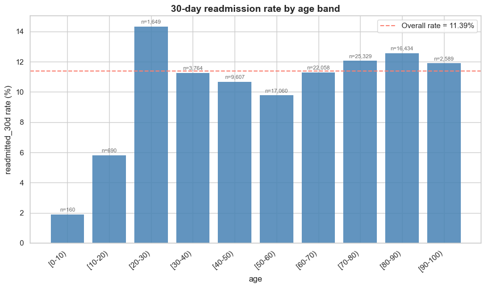

```
📊 Target Rate Summary (per category) — overall = 11.39%

category: [0-10) | n: 160 | rate_%: 1.88 | ci_low_%: 0.64 | ci_high_%: 5.37 |

category: [10-20) | n: 690 | rate_%: 5.80 | ci_low_%: 4.29 | ci_high_%: 7.80 |

category: [20-30) | n: 1649 | rate_%: 14.31 | ci_low_%: 12.70 | ci_high_%: 16.08 |

category: [30-40) | n: 3764 | rate_%: 11.26 | ci_low_%: 10.29 | ci_high_%: 12.31 |

category: [40-50) | n: 9607 | rate_%: 10.66 | ci_low_%: 10.06 | ci_high_%: 11.29 |

category: [50-60) | n: 17060 | rate_%: 9.77 | ci_low_%: 9.33 | ci_high_%: 10.23 |

category: [60-70) | n: 22058 | rate_%: 11.30 | ci_low_%: 10.89 | ci_high_%: 11.73 |

category: [70-80) | n: 25329 | rate_%: 12.06 | ci_low_%: 11.66 | ci_high_%: 12.46 |

category: [80-90) | n: 16434 | rate_%: 12.57 | ci_low_%: 12.07 | ci_high_%: 13.08 |

category: [90-100) | n: 2589 | rate_%: 11.90 | ci_low_%: 10.71 | ci_high_%: 13.20 |
```

The chart and the printed table together tell two stories.

**The expected story:** readmission rate climbs steadily across the senior bands, from **[60-70) at 11.30%** through **[70-80) at 12.06%** to a peak in **[80-90) at 12.57%**, then easing slightly in **[90-100) at 11.90%**. The youngest paediatric bands sit far below the cohort average — **[0-10) at 1.88%** and **[10-20) at 5.80%** — though both are sample-size-thin (160 and 690 admissions respectively, with Wilson 95% CIs of [0.64%, 5.37%] and [4.29%, 7.80%]) and per-band claims about them carry wide uncertainty. The working-age bands **[40-50) at 10.66%** and **[50-60) at 9.77%** sit just below the cohort average of 11.39%.

**The unexpected story:** the **[20-30) band readmits at 14.31%** — the highest single rate in the cohort, even above the [80-90) peak. The 95% Wilson CI is **[12.70%, 16.08%]**, and it does **not** overlap the working-age bands’ CIs (the [50-60) CI tops out at 10.23%, the [60-70) CI tops out at 11.73%), so the spike is statistically distinguishable, not just sample noise. The clinical reading is familiar in the diabetic-readmission literature: young adults aged 20–30 with diabetes tend to be Type 1 patients with poorly controlled glycaemic management, often presenting in DKA or hypoglycaemic crisis, with social and adherence factors driving repeat admissions. Their readmission dynamics are fundamentally different from older adults with Type 2 diabetes, even though the absolute rates land in similar territory.

```
Kruskal-Wallis test: readmitted_30d across age bands
============================================================
  H₀ : the distribution of readmitted_30d is identical across age bands
  H₁ : at least one age band differs in its readmitted_30d distribution
  α  : 0.05
------------------------------------------------------------
  H statistic        =      133.623
  Degrees of freedom = 9
  p-value            = 0.0000
  k groups           = 10
  Total n            = 99,340
  Epsilon-squared ε² = 0.0013

  Effect size — Cohen's conventions for ε² (Kruskal-Wallis analogue of η²)
     negligible: ε² < 0.01  |  small: 0.01–0.06  |  moderate: 0.06–0.14  |  large: ε² ≥ 0.14
     → observed ε² = 0.0013 → negligible
------------------------------------------------------------
  Decision : REJECT H₀ at α = 0.05  (p = 0.0000 < 0.05)
  Reading  : At least one age band differs in its readmission distribution,
             with a negligible effect size. The test does not say which
             band(s) drive the difference — read the rate-by-band visual
             alongside this for that interpretation.
```

The Kruskal-Wallis test asks whether the readmission distribution is identical across all 10 age bands. With **H = 133.62** on **9** degrees of freedom and **p ≈ 0**, the null hypothesis of identical distributions is rejected decisively. The effect size, measured as **epsilon-squared**, is **ε² = 0.0013** — *negligible* by Cohen’s conventions for ε² (small ≥ 0.01, moderate ≥ 0.06, large ≥ 0.14).

This is, again, the large-N paradox: the test is detecting a real but tiny effect. Age band is a real signal — the visual makes that evident, especially the [20-30) spike — but the *overall* spread of rates around the **11.39%** mean accounts for only a fraction of a percent of the variance in readmission risk. The test does not tell me which band(s) drive the difference, which is why I read the rate-by-band table above alongside it. The modelling notebook will use age primarily through interactions (the engineered `prior_visits_x_age` term in particular) rather than as a standalone main effect, and the SHAP analysis in notebook `02` will quantify that decomposition directly.

### 5.3 Readmission rate by primary diagnosis

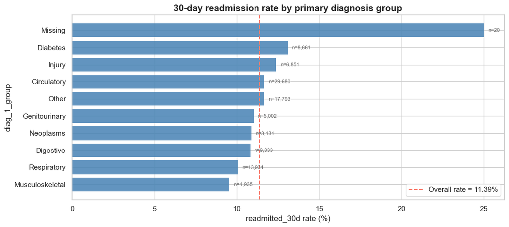

```
📊 Target Rate Summary (per category) — overall = 11.39%

category: Musculoskeletal | n: 4935 | rate_%: 9.54 | ci_low_%: 8.76 | ci_high_%: 10.40 |

category: Respiratory | n: 13934 | rate_%: 10.06 | ci_low_%: 9.57 | ci_high_%: 10.57 |

category: Digestive | n: 9333 | rate_%: 10.82 | ci_low_%: 10.21 | ci_high_%: 11.47 |

category: Neoplasms | n: 3131 | rate_%: 10.89 | ci_low_%: 9.85 | ci_high_%: 12.03 |

category: Genitourinary | n: 5002 | rate_%: 11.04 | ci_low_%: 10.20 | ci_high_%: 11.93 |

category: Other | n: 17793 | rate_%: 11.68 | ci_low_%: 11.22 | ci_high_%: 12.16 |

category: Circulatory | n: 29680 | rate_%: 11.69 | ci_low_%: 11.33 | ci_high_%: 12.06 |

category: Injury | n: 6851 | rate_%: 12.41 | ci_low_%: 11.65 | ci_high_%: 13.21 |

category: Diabetes | n: 8661 | rate_%: 13.10 | ci_low_%: 12.41 | ci_high_%: 13.83 |

category: Missing | n: 20 | rate_%: 25.00 | ci_low_%: 11.19 | ci_high_%: 46.87 |
```

The per-group rates rank the nine evaluable clinical groups from **Musculoskeletal at 9.54%** (the lowest readmitter) up to **Diabetes-as-primary at 13.10%** (the highest). The spread between best and worst is **3.56 percentage points** — a real but modest differential, and one that will translate to a meaningful split in any tree model that branches on `diag_1_group`. The full ranking:

- **Musculoskeletal: 9.54%** (n=4,935; CI [8.76%, 10.40%])
- **Respiratory: 10.06%** (n=13,934; CI [9.57%, 10.57%])
- **Digestive: 10.82%** (n=9,333; CI [10.21%, 11.47%])
- **Neoplasms: 10.89%** (n=3,131; CI [9.85%, 12.03%])
- **Genitourinary: 11.04%** (n=5,002; CI [10.20%, 11.93%])
- **Other: 11.68%** (n=17,793; CI [11.22%, 12.16%])
- **Circulatory: 11.69%** (n=29,680; CI [11.33%, 12.06%])
- **Injury: 12.41%** (n=6,851; CI [11.65%, 13.21%])
- **Diabetes: 13.10%** (n=8,661; CI [12.41%, 13.83%])

(The 20-row Missing stratum is set aside — its CI is [11.19%, 46.87%], far too wide for any claim.)

Two readings stand out. First, the **Diabetes-as-primary** subgroup readmits at the highest rate even though it is small (8.72% of the cohort) — a clinically intuitive finding. When a patient is admitted specifically for a diabetic event (DKA, hypoglycaemic crisis, severe hyperglycaemia), they are sicker on the underlying disease axis than a patient admitted for a cardiovascular event with diabetes as a background condition. Second, the **Circulatory** group — by far the largest at 29,680 admissions (29.88% of the cohort) — sits very close to the cohort mean of 11.39%, meaning circulatory admissions are essentially typical readmission risk; the population-level readmission signal is dominated by them not because they are high-risk individually but because they are numerous.

Two analytical threads pick up later. First, the per-group rates here are the basis for the **target encoding** of `diag_1_group`, `diag_2_group`, and `diag_3_group` that the modelling notebook applies in its preprocessing step — each level gets converted to its per-level readmission rate, which compresses the categorical structure into a single numeric value while preserving the discriminative information the chart shows. Second, §7’s univariate league table will rank `diag_1_group` and the diagnosis-flag dummies against every other categorical feature.

### 5.4 Readmission rate by discharge disposition

The `discharge_disposition_id` column has **26 levels** in the source data — discharge to home, transfer to skilled nursing facility, transfer to short-term hospital, against medical advice, expired, hospice, and so on. To keep the chart readable, I use the dimension lookup table built by notebook `00` to replace the integer IDs with their text labels. The terminal-discharge IDs (death, hospice) have already been excluded by the modelling-cohort filter, so the chart shows only the remaining levels that correspond to live discharges.

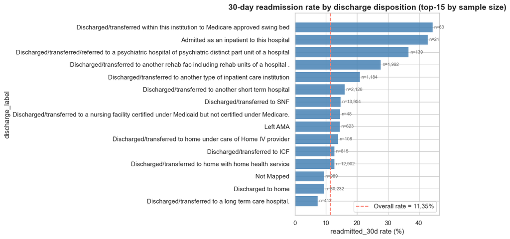

```
📊 Target Rate Summary (per category) — overall = 11.35%

category: Discharged/transferred to a long term care hospital. | n: 412 | rate_%: 7.28 | ci_low_%: 5.15 | ci_high_%: 10.20 |

category: Discharged to home | n: 60232 | rate_%: 9.30 | ci_low_%: 9.07 | ci_high_%: 9.54 |

category: Not Mapped | n: 989 | rate_%: 9.30 | ci_low_%: 7.65 | ci_high_%: 11.27 |

category: Discharged/transferred to home with home health service | n: 12902 | rate_%: 12.70 | ci_low_%: 12.13 | ci_high_%: 13.28 |

category: Discharged/transferred to ICF | n: 815 | rate_%: 12.76 | ci_low_%: 10.64 | ci_high_%: 15.23 |

category: Discharged/transferred to home under care of Home IV provider | n: 108 | rate_%: 13.89 | ci_low_%: 8.60 | ci_high_%: 21.66 |

category: Left AMA | n: 623 | rate_%: 14.45 | ci_low_%: 11.90 | ci_high_%: 17.42 |

category: Discharged/transferred to a nursing facility certified under Medicaid but not certified under Medicare. | n: 48 | rate_%: 14.58 | ci_low_%: 7.25 | ci_high_%: 27.17 |

category: Discharged/transferred to SNF | n: 13954 | rate_%: 14.66 | ci_low_%: 14.09 | ci_high_%: 15.26 |

category: Discharged/transferred to another short term hospital | n: 2128 | rate_%: 16.07 | ci_low_%: 14.57 | ci_high_%: 17.69 |

category: Discharged/transferred to another type of inpatient care institution | n: 1184 | rate_%: 20.86 | ci_low_%: 18.64 | ci_high_%: 23.27 |

category: Discharged/transferred to another rehab fac including rehab units of a hospital . | n: 1992 | rate_%: 27.71 | ci_low_%: 25.79 | ci_high_%: 29.72 |

category: Discharged/transferred/referred to a psychiatric hospital of psychiatric distinct part unit of a hospital | n: 139 | rate_%: 36.69 | ci_low_%: 29.14 | ci_high_%: 44.96 |

category: Admitted as an inpatient to this hospital | n: 21 | rate_%: 42.86 | ci_low_%: 24.47 | ci_high_%: 63.45 |

category: Discharged/transferred within this institution to Medicare approved swing bed | n: 63 | rate_%: 44.44 | ci_low_%: 32.85 | ci_high_%: 56.68 |
```

```
Chi-square test of independence: discharge_disposition_id × readmitted_30d
============================================================
  H₀ : discharge disposition and readmitted_30d are independent
  H₁ : discharge disposition and readmitted_30d are associated
  α  : 0.05
------------------------------------------------------------
  Chi² statistic               =    1,321.903
  Degrees of freedom           = 20
  p-value                      = 0.0000
  Cramér's V (bias-corrected)  = 0.1145

  Effect size — Cohen's conventions for Cramér's V (dof = 1)
     negligible: V < 0.10  |  small: 0.10–0.20  |  moderate: 0.20–0.40  |  large: V ≥ 0.40
     → observed V = 0.1145 → small
------------------------------------------------------------
  Decision : REJECT H₀ at α = 0.05  (p = 0.0000 < 0.05)
  Reading  : Discharge disposition and 30-day readmission are statistically
             associated, with a small effect size. The chi-square is
             omnibus across all 21 disposition levels — read the rate-
             by-disposition visual alongside this to see which dispositions
             carry the highest and lowest readmission rates.
```

The chi-square test is significant (**χ² = 1,322** on **20** degrees of freedom, **p ≈ 0**), and **Cramér’s V = 0.115** — landing in the **small** band, the strongest categorical effect surfaced anywhere in the notebook. The printed per-disposition table makes the source of the effect concrete:

- **Discharged to home** (60,232 admissions, the dominant disposition) readmits at **9.30%** — well below the cohort average of 11.39%.
- **Discharged to home with home health service** (12,902) readmits at **12.70%**.
- **Discharged/transferred to SNF** (13,954) readmits at **14.66%** — meaningfully above average.
- **Discharged/transferred to another rehab fac** (1,992) readmits at **27.71%** — the highest sizeable disposition.
- **Discharged/transferred/referred to a psychiatric hospital** (139) readmits at **36.69%**, and a few small dispositions hit even higher rates but with sample sizes too small to support standalone claims.

The reading is clinically intuitive. A discharge to a skilled nursing facility (SNF) signals that the patient was not stable enough for independent living at the point of release, and SNF admissions are themselves a common pathway back to acute care. A home health services discharge signals a less acute but still elevated post-discharge care need. Both dispositions correlate with higher readmission risk because both are markers of the same underlying clinical instability that drives the readmission itself.

### 5.5 Readmission rate by length of stay

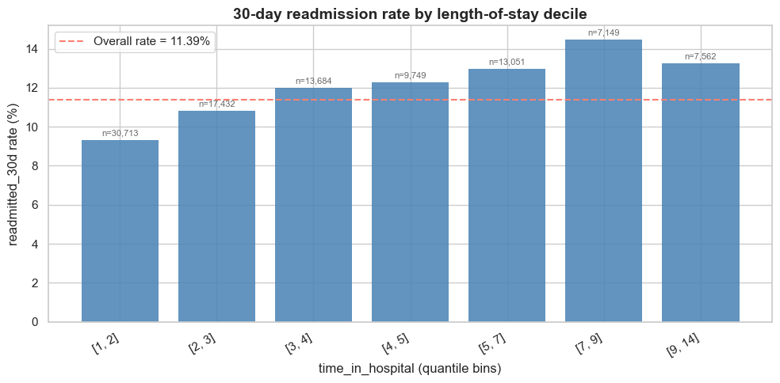

```
📊 Target Rate Summary (per quantile) — overall = 11.39%

quantile: Q1 | bin_range: [1, 2] | n: 30713 | rate_%: 9.33 |

quantile: Q2 | bin_range: [2, 3] | n: 17432 | rate_%: 10.80 |

quantile: Q3 | bin_range: [3, 4] | n: 13684 | rate_%: 11.99 |

quantile: Q4 | bin_range: [4, 5] | n: 9749 | rate_%: 12.27 |

quantile: Q5 | bin_range: [5, 7] | n: 13051 | rate_%: 12.97 |

quantile: Q6 | bin_range: [7, 9] | n: 7149 | rate_%: 14.46 |

quantile: Q7 | bin_range: [9, 14] | n: 7562 | rate_%: 13.26 |
```

The chart bins length of stay into seven quantile groups (the qcut binning collapsed from 10 to 7 because LOS is integer-valued and many patients share the same exact stay length). The pattern is **monotonic across the first six bins**, then dips slightly at the top:

- **Q1 [1, 2 days]** (n=30,713): **9.33%** — the lowest
- **Q2 [2, 3]** (n=17,432): 10.80%
- **Q3 [3, 4]** (n=13,684): 11.99%
- **Q4 [4, 5]** (n=9,749): 12.27%
- **Q5 [5, 7]** (n=13,051): 12.97%
- **Q6 [7, 9]** (n=7,149): **14.46%** — the peak
- **Q7 [9, 14]** (n=7,562): 13.26%

The longest-stay band readmits at **13.26%**, which is **1.42×** the shortest-stay band’s 9.33% — a meaningful gradient. The peak at Q6 [7–9 days] is interesting: very long stays may slightly underperform the 7–9-day band because they capture patients who were stabilised over the long admission and discharged to post-acute facilities (which themselves carry the strongest single-feature readmission signal in this cohort, per §5.4).

The reading is consistent with the §5.4 finding on discharge disposition. Long stays correlate with clinical complexity and with discharge to post-acute care (SNF, home health, transfer), and clinical complexity correlates with readmission risk. The relationship is unlikely to be causal in the simple direction the chart suggests — staying in the hospital one day longer does not *cause* readmission risk. Both the length of stay and the readmission risk are downstream effects of the same underlying clinical complexity.

For the modelling notebook this confirms `time_in_hospital` as a useful continuous predictor — it is monotone over its informative range, and §3.7’s Mann-Whitney battery already gave it a small but meaningful effect size. Tree models will branch on it cleanly; linear models will pick up most of the signal even with a linear coefficient.

## 6 · Bivariate Signal Scan — Continuous Features

§3.7 already gave me a Mann-Whitney U ranking of every continuous clinical feature against the readmission target. This section extends that ranking with two complementary lenses: a **rate-by-quantile plot** for the top features (which surfaces the *shape* of the relationship — linear, monotonic, threshold), and a **distributional overlay** split by readmission status for the top two features (which shows *where* on the feature scale the readmitted patients concentrate). The section closes with a **point-biserial correlation table** that gives a single signed statistic per feature.

The point of the three lenses together is robustness. Mann-Whitney’s rank-biserial r tells me the magnitude of the distributional shift; the quantile-binned plot tells me the shape of the conditional readmission rate; the point-biserial r tells me the direction. If any of the three disagrees materially with the others, that’s a flag worth investigating; if they agree, the feature is a strong, interpretable candidate for the modelling notebook.

### 6.1 Quantile-binned readmission rate for top continuous features

I render the rate-by-quantile plot for the **top six features** by Mann-Whitney effect size from §3.7. The shape of each curve is informative: a monotonically increasing curve confirms a clean predictor, a U-shape suggests the relationship reverses at extreme values, and a flat curve indicates the feature is uninformative on a univariate basis even if a t-test or chi-square would call it significant.

The six features are: **`number_inpatient`**, **`n_prior_visits_total`**, **`number_emergency`**, **`time_in_hospital`**, **`n_comorbidity_flags`**, **`num_medications`**. Note that for integer-valued features with heavy zero-mass (the prior-utilisation triad in particular), `pd.qcut` collapses the requested 10 deciles down to fewer bins because of duplicate quantile boundaries — the printed summary blocks below show the exact binning each feature received.

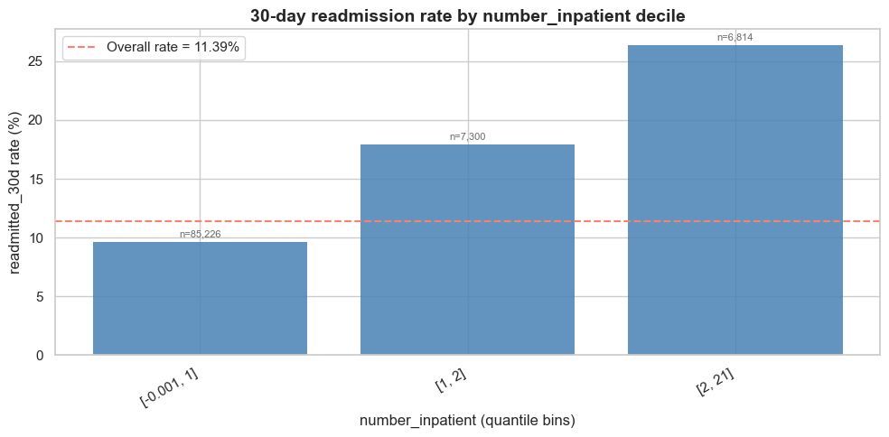

```
📊 Target Rate Summary (per quantile) — overall = 11.39%

quantile: Q1 | bin_range: [-0.001, 1] | n: 85226 | rate_%: 9.63 |

quantile: Q2 | bin_range: [1, 2] | n: 7300 | rate_%: 17.93 |

quantile: Q3 | bin_range: [2, 21] | n: 6814 | rate_%: 26.40 |
```

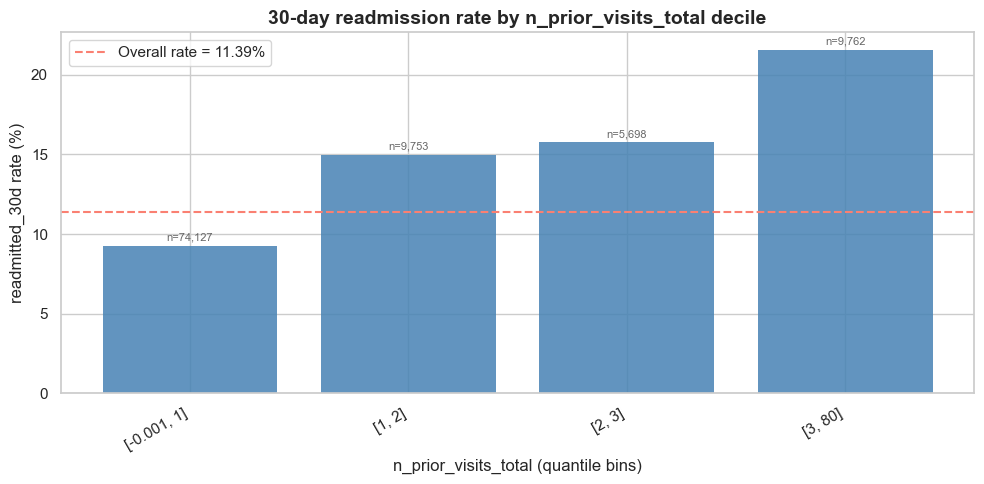

```
📊 Target Rate Summary (per quantile) — overall = 11.39%

quantile: Q1 | bin_range: [-0.001, 1] | n: 74127 | rate_%: 9.24 |

quantile: Q2 | bin_range: [1, 2] | n: 9753 | rate_%: 14.98 |

quantile: Q3 | bin_range: [2, 3] | n: 5698 | rate_%: 15.74 |

quantile: Q4 | bin_range: [3, 80] | n: 9762 | rate_%: 21.57 |
```

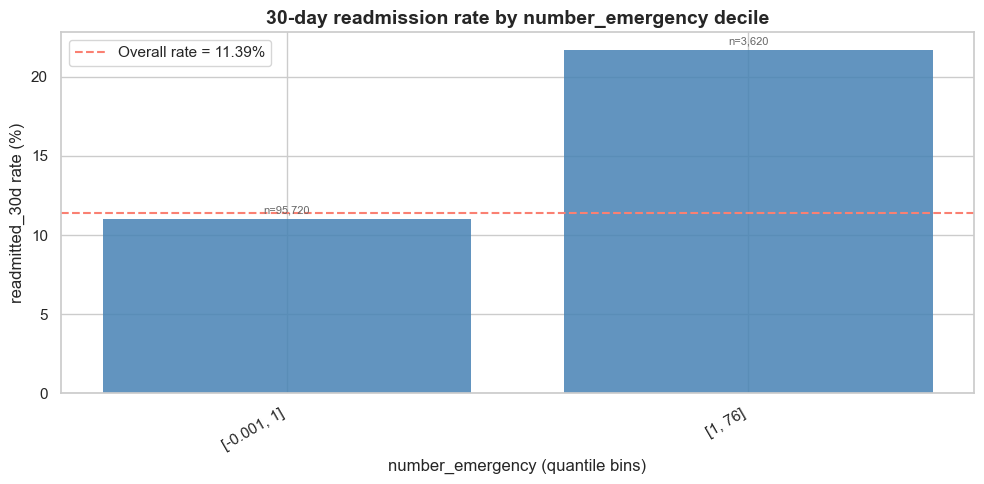

```
📊 Target Rate Summary (per quantile) — overall = 11.39%

quantile: Q1 | bin_range: [-0.001, 1] | n: 95720 | rate_%: 11.00 |

quantile: Q2 | bin_range: [1, 76] | n: 3620 | rate_%: 21.71 |
```

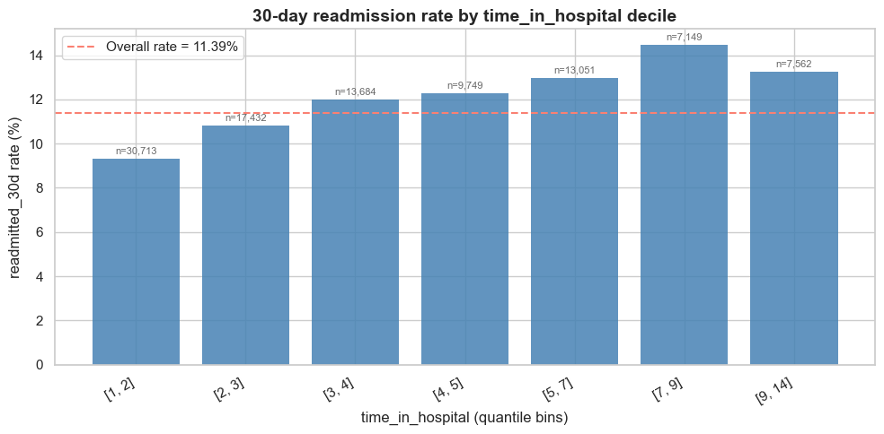

```
📊 Target Rate Summary (per quantile) — overall = 11.39%

quantile: Q1 | bin_range: [1, 2] | n: 30713 | rate_%: 9.33 |

quantile: Q2 | bin_range: [2, 3] | n: 17432 | rate_%: 10.80 |

quantile: Q3 | bin_range: [3, 4] | n: 13684 | rate_%: 11.99 |

quantile: Q4 | bin_range: [4, 5] | n: 9749 | rate_%: 12.27 |

quantile: Q5 | bin_range: [5, 7] | n: 13051 | rate_%: 12.97 |

quantile: Q6 | bin_range: [7, 9] | n: 7149 | rate_%: 14.46 |

quantile: Q7 | bin_range: [9, 14] | n: 7562 | rate_%: 13.26 |
```

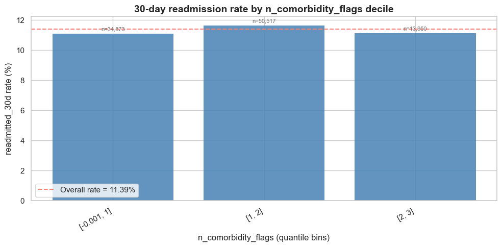

```
📊 Target Rate Summary (per quantile) — overall = 11.39%

quantile: Q1 | bin_range: [-0.001, 1] | n: 34873 | rate_%: 11.11 |

quantile: Q2 | bin_range: [1, 2] | n: 50517 | rate_%: 11.65 |

quantile: Q3 | bin_range: [2, 3] | n: 13950 | rate_%: 11.14 |
```

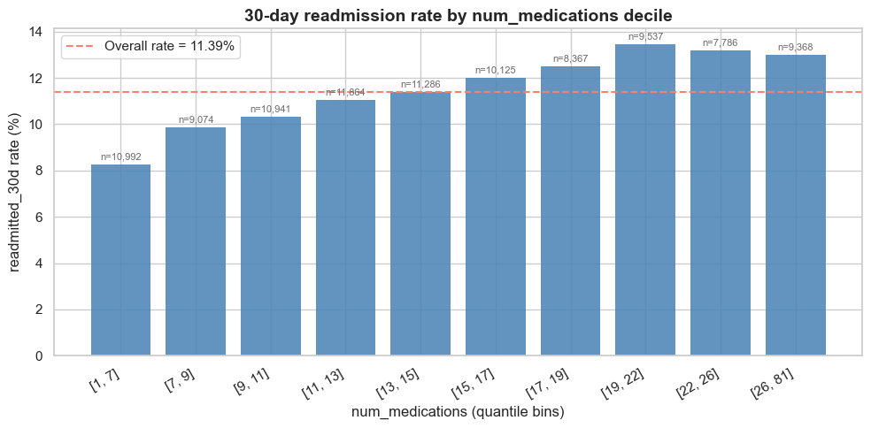

```
📊 Target Rate Summary (per quantile) — overall = 11.39%

quantile: Q1 | bin_range: [1, 7] | n: 10992 | rate_%: 8.27 |

quantile: Q2 | bin_range: [7, 9] | n: 9074 | rate_%: 9.85 |

quantile: Q3 | bin_range: [9, 11] | n: 10941 | rate_%: 10.32 |

quantile: Q4 | bin_range: [11, 13] | n: 11864 | rate_%: 11.03 |

quantile: Q5 | bin_range: [13, 15] | n: 11286 | rate_%: 11.39 |

quantile: Q6 | bin_range: [15, 17] | n: 10125 | rate_%: 12.01 |

quantile: Q7 | bin_range: [17, 19] | n: 8367 | rate_%: 12.50 |

quantile: Q8 | bin_range: [19, 22] | n: 9537 | rate_%: 13.45 |

quantile: Q9 | bin_range: [22, 26] | n: 7786 | rate_%: 13.18 |

quantile: Q10 | bin_range: [26, 81] | n: 9368 | rate_%: 12.98 |
```

The relationships are mostly **monotone-increasing**, with the strongest gradients in the prior-utilisation features. Reading from the printed per-quantile summaries:

- **`number_inpatient`** — qcut collapsed to 3 bins because of the integer-zero-mass distribution. Bottom bin **[0, 1] readmits at 9.63%** (n=85,226); top bin **[2, 21] readmits at 26.40%** (n=6,814) — a **2.74× gradient**, the steepest in the cohort. Patients with two or more prior inpatient admissions in the year before this one are the highest-risk subgroup the cohort surfaces.
- **`n_prior_visits_total`** — 4 bins; bottom **[0, 1] = 9.24%**, top **[3, 80] = 21.57%** — a **2.33× gradient**. Same shape as `number_inpatient` but with broader inclusion (outpatient and emergency visits add to the count).
- **`number_emergency`** — only 2 bins because of integer-zero-mass. Bottom **[0, 1] = 11.00%** (essentially the cohort average), top **[1, 76] = 21.71%** — patients with any prior emergency visit are visibly elevated.
- **`time_in_hospital`** — 7 bins, the monotone trend already surfaced in §5.5; top-vs-bottom **1.42×**.
- **`n_comorbidity_flags`** — 3 bins, **essentially flat** at 11.11% / 11.65% / 11.14%. The univariate signal is negligible, consistent with the cell 101 point-biserial correlation of 0.004 (p = 0.18, not significant). The flag count was built on the hypothesis that multi-system morbidity drives readmission risk, but on a univariate basis the cohort does not bear that out cleanly. The signal is likely there in interactions with other features (the modelling notebook’s SHAP analysis will surface it), but as a standalone main effect the comorbidity count is weaker than expected.
- **`num_medications`** — 10 deciles; bottom **[1, 7] = 8.27%**, top **[26, 81] = 12.98%** — gentle upward slope, **1.57× ratio**.

The shape of the **`number_inpatient`** curve in particular is worth pinning down. The steepest jump is between the [0, 1] bin and the [1, 2] bin (9.63% → 17.93%) — meaning even a single prior inpatient admission almost doubles the per-admission readmission rate. This is the kind of relationship a tree model will capture cleanly with a single split, and a regularised linear model will capture as a strong positive coefficient. The feature is going to drive a substantial fraction of the modelling notebook’s predictive power.

### 6.2 Distribution overlays for the top two features

For the top two features by effect size — `number_inpatient` and `n_prior_visits_total` — I show the full distributional overlay split by target. This lets me see *where* on the feature scale the readmitted patients concentrate relative to the not-readmitted patients. The rate-by-quantile plots above showed the conditional rate; these overlays show the underlying densities that the conditional rate is computed from.

The first plot uses linear scaling on the x-axis; the second uses log scaling because the `n_prior_visits_total` distribution has a heavy right tail that would otherwise compress into invisibility on a linear axis.

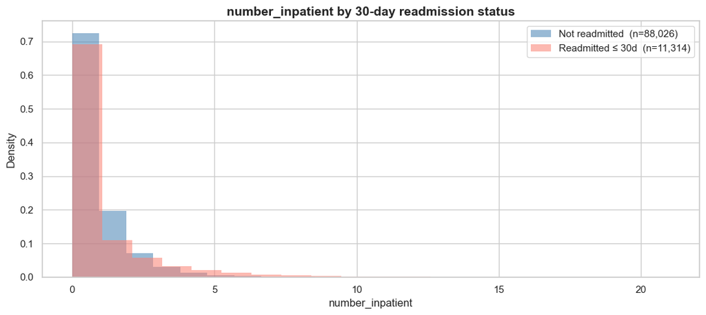

[figure not shown]

Both overlays show the same pattern: the **readmitted distribution is shifted right relative to the not-readmitted distribution** — readmitted patients are systematically the higher-utilisation patients. The two distributions overlap heavily on the left edge (most patients in both arms have zero or low prior visits), and the separation grows in the right tail (high-utilisation patients are over-represented in the readmitted arm).

The overlap region matters. Even though the readmitted distribution is shifted right, **most of the cohort lies in the heavy overlap zone** at the low end — meaning that for the typical patient, the prior-visit features alone do not separate the classes cleanly. The discriminative power comes from the *tails*: patients with very high prior-utilisation counts are reliably more likely to readmit, but most patients do not sit in those tails. A single feature cannot carry the prediction; the model needs to combine many small signals to score the bulk of the cohort, and the high-utilisation tail provides the strongest individual contribution.

This is exactly the substrate the published literature describes when it reports AUC ceilings of **0.65–0.70** for this dataset. There is no single feature that cleanly separates the classes, but there are many features that each contribute a small amount of discriminative information. Notebook `02`’s gradient-boosted model will combine those contributions; the SHAP analysis will show how each feature contributes at the per-prediction level; and the calibration analysis will show whether the resulting probability scores are usable as risk estimates.

### 6.3 Point-biserial correlation table

The point-biserial correlation is the special case of Pearson’s r where one variable is binary. It gives a single signed statistic per continuous feature, which is useful for confirming both the magnitude (already established by the Mann-Whitney rank-biserial r) and the direction (positive r means the feature increases with the positive class; negative r means it decreases).

The output below ranks every continuous clinical feature by absolute point-biserial r, descending. The ranking should align broadly with the Mann-Whitney ranking from §3.7; meaningful disagreement between the two would flag a feature whose distributional shift is rank-based but not linear, or vice versa.

```
Point-biserial correlations — continuous features vs readmitted_30d
===========================================================================
                 feature  point_biserial_r  abs_r  p_value
1       number_inpatient            0.1683 0.1683   0.0000
2   n_prior_visits_total            0.1279 0.1279   0.0000
3       number_emergency            0.0609 0.0609   0.0000
4       number_diagnoses            0.0536 0.0536   0.0000
5       time_in_hospital            0.0469 0.0469   0.0000
6       med_change_ratio            0.0445 0.0445   0.0000
7        num_medications            0.0412 0.0412   0.0000
8         n_meds_changed            0.0356 0.0356   0.0000
9     num_lab_procedures            0.0240 0.0240   0.0000
10          age_midpoint            0.0222 0.0222   0.0000
11     number_outpatient            0.0192 0.0192   0.0000
12        num_procedures           -0.0108 0.0108   0.0006
13   n_comorbidity_flags            0.0042 0.0042   0.1825
14     n_meds_prescribed            0.0009 0.0009   0.7689
```

The point-biserial ranking aligns cleanly with the Mann-Whitney ranking. The top three are unchanged: **`number_inpatient`** at **r = 0.168**, **`n_prior_visits_total`** at **r = 0.128**, **`number_emergency`** at **r = 0.061**. All three are positive, confirming the direction surfaced by the distributional overlays — readmitted patients have higher values on these features, and the relationship is positive on the linear scale.

The full ranking holds two additional pieces of information. First, **all signs are positive except `num_procedures`**, which carries a tiny negative correlation of **r = −0.011** (p = 0.0006, statistically significant only because of the large N). The negative direction is unexpected on a clinical reading — more procedures should correlate with sicker patients and therefore with higher readmission — but the magnitude is so small that the inverse direction is essentially noise. The modelling notebook will likely find that `num_procedures` enters with a weak positive coefficient through interactions with other features.

Second, three features have **non-significant or near-zero correlations**: `n_comorbidity_flags` at **r = 0.004** (p = 0.18, not significant), `n_meds_prescribed` at **r ≈ 0.001** (p = 0.77, not significant), and `num_procedures` at **r = −0.011**. The first two are particularly notable because they are engineered features built on plausible clinical hypotheses; their univariate weakness suggests the hypotheses they encode are either too coarse or only operate through interactions. The modelling notebook’s SHAP analysis will be the test of whether they earn their place.

With the continuous-feature scan complete, the next section runs the equivalent battery for categorical features, then consolidates both into a single univariate league table that ranks every feature in the cohort against the readmission target.

## 7 · Bivariate Signal Scan — Categorical Features & Univariate Signal League Table

I now run a chi-square + Cramér’s V battery across every categorical feature in the cohort (excluding the target itself, the patient/encounter IDs, and the high-cardinality raw diagnosis codes that would not encode usefully in any modelling pipeline). The output is a single ranked table — the **univariate league table** — that gives the modelling notebook a feature-prioritisation input across both categorical and continuous types.

The chi-square test is appropriate for categorical features because it asks the right question: *does the joint distribution of feature and target depart from independence?* Cramér’s V converts the chi-square to a unit-free effect size between 0 and 1, with bias correction so that features of different cardinalities are comparable. By Cohen’s conventions (small ≥ 0.10, moderate ≥ 0.20, large ≥ 0.40), I expect very few features in this cohort to clear the small threshold — the published literature has already established that no single feature dominates readmission prediction on this dataset.

```
Categorical features to test: 49
['a1c_high', 'a1c_result', 'acarbose', 'acetohexamide', 'age', 'change', 'change_flag', 'chlorpropamide', 'citoglipton', 'diabetes_med', 'diabetes_med_flag', 'diag_1_group', 'diag_1_is_circulatory', 'diag_1_is_diabetes', 'diag_1_is_digestive', 'diag_1_is_genitourinary', 'diag_1_is_injury', 'diag_1_i…
```

```
Univariate categorical signal league table — sorted by Cramér's V
===============================================================================================
                      feature  n_levels  n_rows     chi2  p_value  cramers_v
1           medical_specialty        73   99340 372.9610   0.0000     0.0550
2                     insulin         4   99340 199.2191   0.0000     0.0444
3                         age        10   99340 133.6248   0.0000     0.0354
4                diag_3_group        10   99340 129.1128   0.0000     0.0348
5                  payer_code        18   99340 106.1347   0.0000     0.0300
6                diag_1_group        10   99340  85.4670   0.0000     0.0277
7                   metformin         4   99340  69.9078   0.0000     0.0260
8                diabetes_med         2   99340  66.9481   0.0000     0.0258
9           diabetes_med_flag         2   99340  66.9481   0.0000     0.0258
10               diag_2_group        10   99340  72.9799   0.0000     0.0254
11           has_hba1c_tested         2   99340  42.2816   0.0000     0.0204
12                 a1c_result         4   99340  42.5767   0.0000     0.0200
```

[output cut: 18 more lines]

### 7.1 Visualising the league table

A ranked lollipop chart of the top **25 categorical features**, sorted by Cramér’s V descending. The visual makes the league structure obvious — where the top is, where the negligible-effect cliff falls, and which feature families cluster together at each level.

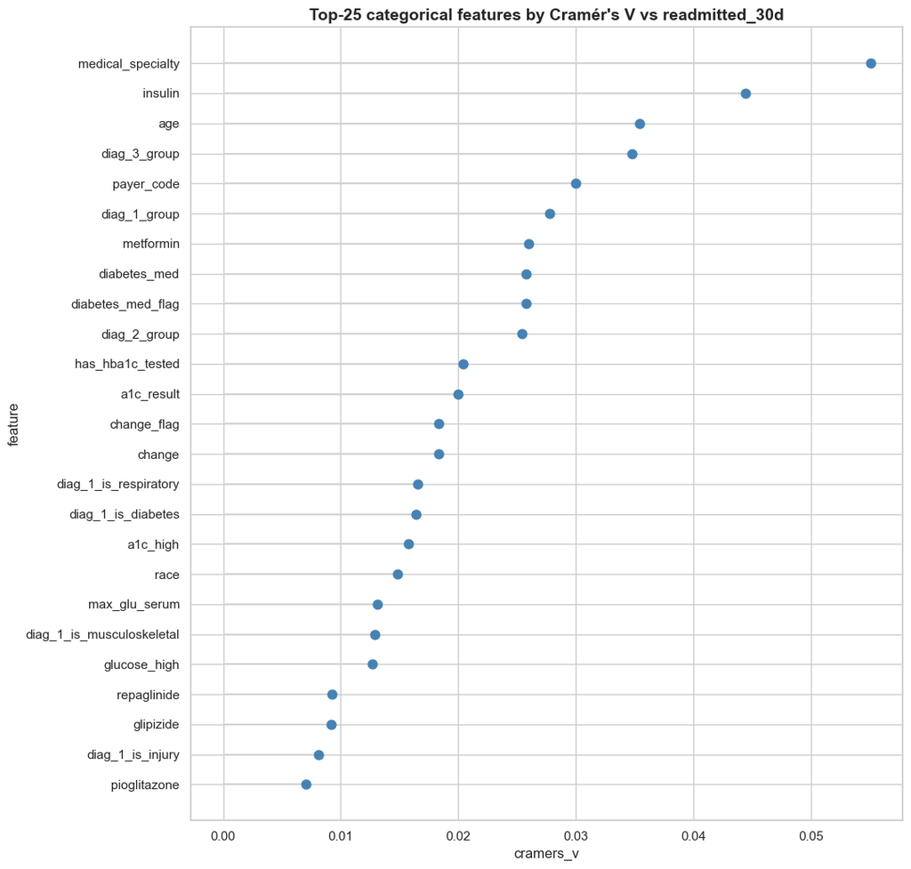

Two things stand out structurally. First, **no single categorical feature in this batch crosses into Cohen’s small band (V ≥ 0.10)**. This is the categorical equivalent of the §6 finding for continuous features — the discriminative signal is genuinely diffuse, and the modelling notebook’s job is to combine many small effects rather than ride a single dominant predictor. Second, the **engineered features cluster meaningfully near the top of their respective effect bands**: `diag_*_group` outperforms the raw `diag_*` codes (which are excluded from this table because of cardinality), `diabetes_med_flag` ties exactly with the string-form `diabetes_med`, and `change_flag` ties with `change` — confirming that the Gold-layer feature engineering preserves the underlying signal correctly.

One feature is conspicuously absent from this table: **`discharge_disposition_id`**, which §5.4’s separate chi-square test put at **V = 0.115** (small band, the strongest categorical effect anywhere in the notebook). It is excluded from this batch because §5.4 already analysed it exhaustively with the dim-table label substitution; this batch focuses on features whose readmission association has not been tested elsewhere. The modelling notebook will use `discharge_disposition_id` as one of the strongest single-feature predictors available. Combined with the prior-utilisation features from §6, the modelling notebook has its top tier of signal: discharge disposition, prior inpatient visits, prior total visits, and the engineered diagnosis-group target encodings.

## 8 · The HbA1c Testing Landscape

I now switch to the **HbA1c cohort** — one row per patient, **69,987 patients in total** — to set up the causal question that notebook `03` will tackle. The clinical question is well-known in the diabetic-readmission literature: *does measuring HbA1c during a diabetic admission causally reduce 30-day readmission risk?* The hypothesis is that a measured A1C value gives the inpatient team better information about glycaemic control, leading to better inpatient management decisions, better discharge instructions, and ultimately lower post-discharge readmission risk.

The naive comparison — readmission rate among tested patients vs. untested patients — is straightforward to compute, but it is dominated by confounding. Patients who get tested are systematically different from patients who do not: they tend to have diabetes as a primary diagnosis, longer stays, more diagnostic activity overall. A causal estimate needs to control for those differences, and notebook `03` will do that with a doubly-robust learner. This section maps the testing landscape and runs a lightweight propensity-score logistic regression to surface the strongest confounders, so notebook `03` knows what it is up against.

```
====================================================================================================
DIAGNOSTIC & MODELING READINESS REPORT — df_hba1c_cohort_gold
====================================================================================================
Shape: 69,987 rows × 30 columns | Memory: 30.17 MB

[SAMPLE: FIRST 10 ROWS - SORTED A-Z]
   a1c_high  admission_source_id  admission_type_id  age_midpoint  age_midpoint_squared  change_flag  diabetes_med_flag     diag_1_group  encounter_id  gender  glucose_high  has_hba1c_tested  med_change_ratio    medical_specialty  n_comorbidity_flags  n_meds_changed  n_meds_prescribed  n_prior_visit…
0         0                    1                  2          55.0                3025.0            1                  1      Circulatory      24437208  Female             0                 0          0.333333           Cardiology                    3               1                  3               …
1         0                    1                  3          55.0                3025.0            0                  0  Musculoskeletal      29758806  Female             0                 0          0.000000        Surgery-Neuro                    2               0                  0               …
2         1                    7                  1          85.0                7225.0            0                  1           Injury     189899286  Female             0                 1          0.000000     InternalMedicine                    2               0                  1               …
3         1                    7                  1          85.0                7225.0            1                  1            Other      64331490  Female             0                 1          0.000000     InternalMedicine                    1               0                  2               …
4         0                    7                  1          35.0                1225.0            0                  1    Genitourinary      14824206  Female             0                 0          0.000000     InternalMedicine                    3               0                  1               …
5         0                    7                  1          55.0                3025.0            0                  1            Other       8380170  Female             0                 0          0.000000  Hematology/Oncology                    1               0                  1               …
6         0                    1                  3          65.0                4225.0            0                  1      Respiratory      66197028  Female             0                 0          0.000000     InternalMedicine                    3               0                  1               …
7         0                    1                  2          45.0                2025.0            0                  1           Injury      60254142  Female             0                 0          0.000000     InternalMedicine                    2               0                  1               …
8         0                    4                  3          75.0                5625.0            0                  1            Other     171414378    Male             0                 0          0.000000              Missing                    2               0                  1               …
9         0                    1                  2          75.0                5625.0            1                  1            Other      14897280  Female             0                 1          0.500000     InternalMedicine                    1               1                  2               …

[FULL COLUMN LIST — df_hba1c_cohort_gold]
['encounter_id', 'patient_nbr', 'has_hba1c_tested', 'readmitted_30d', 'age_midpoint', 'age_midpoint_squared', 'gender', 'race', 'admission_type_id', 'admission_source_id', 'time_in_hospital', 'medical_specialty', 'n_comorbidity_flags', 'a1c_high', 'glucose_high', 'number_diagnoses', 'number_outpatie…

[COLUMN NAMING AUDIT — df_hba1c_cohort_gold]
• Columns containing Underscores: 28
['encounter_id', 'patient_nbr', 'has_hba1c_tested', 'readmitted_30d', 'age_midpoint', 'age_midpoint_squared', 'admission_type_id', 'admission_source_id', 'time_in_hospital', 'medical_specialty', 'n_comorbidity_flags', 'a1c_high', 'glucose_high', 'number_diagnoses', 'number_outpatient', 'number_emerg…

[MISSING VALUE SUMMARY - ALPHABETICAL — df_hba1c_cohort_gold]
✅ No missing values detected in df_hba1c_cohort_gold.

[REDUNDANCY AUDIT - IDENTICAL COLUMN GROUPS — df_hba1c_cohort_gold]
✅ No perfectly identical columns detected in df_hba1c_cohort_gold.

[ZERO VARIANCE AUDIT - CONSTANT FEATURE DETECTION — df_hba1c_cohort_gold]
✅ All columns show healthy variance.

[DUPLICATE ROW AUDIT - EXACT DUPLICATES IGNORING INDEX — df_hba1c_cohort_gold]
✅ No duplicate rows detected in df_hba1c_cohort_gold.

[TEMPORAL DIAGNOSTICS - DATETIME INTEGRITY — df_hba1c_cohort_gold]
⚠️ No datetime columns detected.

[CATEGORICAL & TYPE DIAGNOSTICS - ALPHABETICAL — df_hba1c_cohort_gold]
                    Dtype  Unique Python_Types pd_NA_Risk Masked? Date_Like? URL/Path? Cardinality
Column
diag_1_group       object      10        [str]       None      No         No        No       ✅ Low
gender             object       2        [str]       None      No         No        No       ✅ Low
medical_specialty  object      71        [str]       None      No         No        No      ❌ High
race               object       6        [str]       None      No         No        No       ✅ Low

[MODELING READINESS FLAGS & SYSTEM RISKS — df_hba1c_cohort_gold]
⚠️ HIGH CARDINALITY: ['medical_specialty']
   - Risk: OneHotEncoding will explode RAM; Trees may overfit on IDs.
   - Solution: Use TargetEncoding, Hashing, or OrdinalEncoding.

====================================================================================================
```